# IODS course project

Kaapo Seppänen

# About the project (Week 1)

## Motivation and objectives

I enrolled in the Introduction to Open Data Science to learn the basics of data science and using tools such as R and Git. Also five credits to the Transferable Skills provided some motivation since I need them to complete my studies. I found a link to the course page from an email that specified all the courses compatible with Transferable Skills.

I don’t have that much experience in data science and basically zero experience with R so I’m expecting to learn a lot during the course. However, I’m very experienced in coding so learning R shouldn’t be that difficult to me.

## Learning R

Learning R from the book *R for Health Data Science* was very pleasant and easy to follow. The book is very accessible since the reader wasn’t expected to know almost any coding. However, for a experienced coder a more condensed tutorial would perhaps have transferred the information more efficiently. Anyhow, I think the book with the complementary exercises are a great way to learn using R.

My favorite topic was *Different types of plots* since it’s always nice to create pretty looking plots. The most difficult part was probably *R basics* as this is my first time coding in R. It takes a while to get used to a new language.

## GitHub repository

A link to my GitHub repository: https://github.com/kaapo96/IODS-project

# Analysis of learning data (Week 2)

In this Analysis exercise, I analyze the data obtained from a survey studying the influence of different learning methods and personal attitudes to the performance in a course exam on a statistics course lectured in 2014.

## Loading the data

First, I load the data with the `read_csv` function from the `readr` library and print its structure and dimensions:

```r
# load the readr library
library(readr)

# load the data file
learning2014 <- read_csv("data/learning2014.csv")
# print the structure
str(learning2014)
```

```
## spc_tbl_ [166 × 7] (S3: spec_tbl_df/tbl_df/tbl/data.frame)
##  $ gender  : chr [1:166] "F" "M" "F" "M" ...
##  $ age     : num [1:166] 53 55 49 53 49 38 50 37 37 42 ...
##  $ attitude: num [1:166] 3.7 3.1 2.5 3.5 3.7 3.8 3.5 2.9 3.8 2.1 ...
##  $ deep    : num [1:166] 3.58 2.92 3.5 3.5 3.67 ...
##  $ stra    : num [1:166] 3.38 2.75 3.62 3.12 3.62 ...
##  $ surf    : num [1:166] 2.58 3.17 2.25 2.25 2.83 ...
##  $ points  : num [1:166] 25 12 24 10 22 21 21 31 24 26 ...
##  - attr(*, "spec")=
##   .. cols(
##   ..   gender = col_character(),
##   ..   age = col_double(),
##   ..   attitude = col_double(),
##   ..   deep = col_double(),
##   ..   stra = col_double(),
##   ..   surf = col_double(),
##   ..   points = col_double()
##   .. )
##  - attr(*, "problems")=<externalptr>
```

```r
# print the dimensions
dim(learning2014)
```

```
## [1] 166   7
```

The data consists of 7 variables and 166 observations. The variables are: `gender`, `age`, `attitude`, `deep`, `stra`, `surf`, and `points`. The first two variables are self-explanatory and rest are defined as

- `attitude`: Attitude towards statistics on a scale from 1 to 5. Obtained as a mean of answers to ten questions.
- `deep`: Mean of answers to twelve questions related to deep level learning, in particular seeking meaning, relating ideas, and using evidence. Scale: 1-5.
- `surf`: Mean of answers to twelve questions related to surface level learning, specifically the lack of purpose, unrelated memorizing, and syllabus-boundedness. Scale: 1-5.
- `stra`: Mean of answers to eight questions about how strategic the approach of the student is, assessing organization and time-management. Scale: 1-5.
- `points`: Points obtained from the course exam.

## Visualizing data

Next, I show a graphical overview and summary of the data

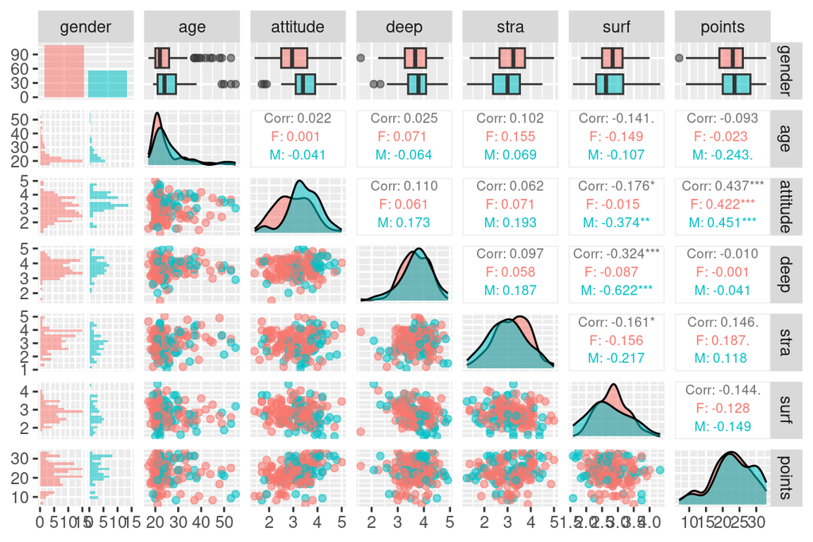

```r
# access the GGally and ggplot2 libraries
library(GGally)
library(ggplot2)

# create a plot matrix with ggpairs()
p <- ggpairs(learning2014, mapping = aes(col = gender, alpha = 0.3), lower = list(combo = wrap("facethist", bins = 20)), upper = list(continuous = wrap("cor", size = 2.5)))

# draw the plot
p
```

```r
# print a summary
summary(learning2014)
```

```
##     gender               age           attitude          deep
##  Length:166         Min.   :17.00   Min.   :1.400   Min.   :1.583
##  Class :character   1st Qu.:21.00   1st Qu.:2.600   1st Qu.:3.333
##  Mode  :character   Median :22.00   Median :3.200   Median :3.667
##                     Mean   :25.51   Mean   :3.143   Mean   :3.680
##                     3rd Qu.:27.00   3rd Qu.:3.700   3rd Qu.:4.083
##                     Max.   :55.00   Max.   :5.000   Max.   :4.917
##       stra            surf           points
##  Min.   :1.250   Min.   :1.583   Min.   : 7.00
##  1st Qu.:2.625   1st Qu.:2.417   1st Qu.:19.00
##  Median :3.188   Median :2.833   Median :23.00
##  Mean   :3.121   Mean   :2.787   Mean   :22.72
##  3rd Qu.:3.625   3rd Qu.:3.167   3rd Qu.:27.75
##  Max.   :5.000   Max.   :4.333   Max.   :33.00
```

The dataset mostly includes young students with median age at 22. Also female participants have a clear majority over male ones. Between different variables, the strongest correlation is between `attitude` and `points` irrespective of gender, which indicates that a motivated student is likely to perform well in the course exam. On the other hand, the strongest anti-correlation is between `surf` and `deep`, suggesting that the two attributes are exclusive on some level. This anti-correlation is much higher among males than females, which I can’t explain.

## Fitting a linear regression model

Next, I fit a linear regression model, where `points` is the target variable and `attitude`, `stra`, and `surf` are the explanatory variables. These three variables are chosen as explanatory since they have the highest absolute correlation with the target variable. Fitting the model and printing out the summary gives

```r
# create a regression model with multiple explanatory variables
my_model <- lm(points ~ attitude + stra + surf, data = learning2014)

# print out a summary of the model
summary(my_model)
```

```
##
## Call:
## lm(formula = points ~ attitude + stra + surf, data = learning2014)
##
## Residuals:
##      Min       1Q   Median       3Q      Max
## -17.1550  -3.4346   0.5156   3.6401  10.8952
##
## Coefficients:
##             Estimate Std. Error t value Pr(>|t|)
## (Intercept)  11.0171     3.6837   2.991  0.00322 **
## attitude      3.3952     0.5741   5.913 1.93e-08 ***
## stra          0.8531     0.5416   1.575  0.11716
## surf         -0.5861     0.8014  -0.731  0.46563
## ---
## Signif. codes:  0 '***' 0.001 '**' 0.01 '*' 0.05 '.' 0.1 ' ' 1
##
## Residual standard error: 5.296 on 162 degrees of freedom
## Multiple R-squared:  0.2074, Adjusted R-squared:  0.1927
## F-statistic: 14.13 on 3 and 162 DF,  p-value: 3.156e-08
```

According to the regression model, only one of the three variables, namely `attitude`, has a statistically significant relationship with the target variable `points`. Its P-value, a particular statistical test measuring the accuracy of the fitted model parameters, is remarkably low, meaning a high significance. The P-values of the other two variables are high, indicating that there is barely any statistical significance in their relationship to `points`.

By removing the insignificant variables from the regression model, I perform the fitting with only one explanatory variable `attitude`:

```r
# create a regression model with one explanatory variable
my_model2 <- lm(points ~ attitude, data = learning2014)

# print out a summary of the model
summary(my_model2)
```

```
##
## Call:
## lm(formula = points ~ attitude, data = learning2014)
##
## Residuals:
##      Min       1Q   Median       3Q      Max
## -16.9763  -3.2119   0.4339   4.1534  10.6645
##
## Coefficients:
##             Estimate Std. Error t value Pr(>|t|)
## (Intercept)  11.6372     1.8303   6.358 1.95e-09 ***
## attitude      3.5255     0.5674   6.214 4.12e-09 ***
## ---
## Signif. codes:  0 '***' 0.001 '**' 0.01 '*' 0.05 '.' 0.1 ' ' 1
##
## Residual standard error: 5.32 on 164 degrees of freedom
## Multiple R-squared:  0.1906, Adjusted R-squared:  0.1856
## F-statistic: 38.61 on 1 and 164 DF,  p-value: 4.119e-09
```

To visualize the linear regression model, I draw a plot:

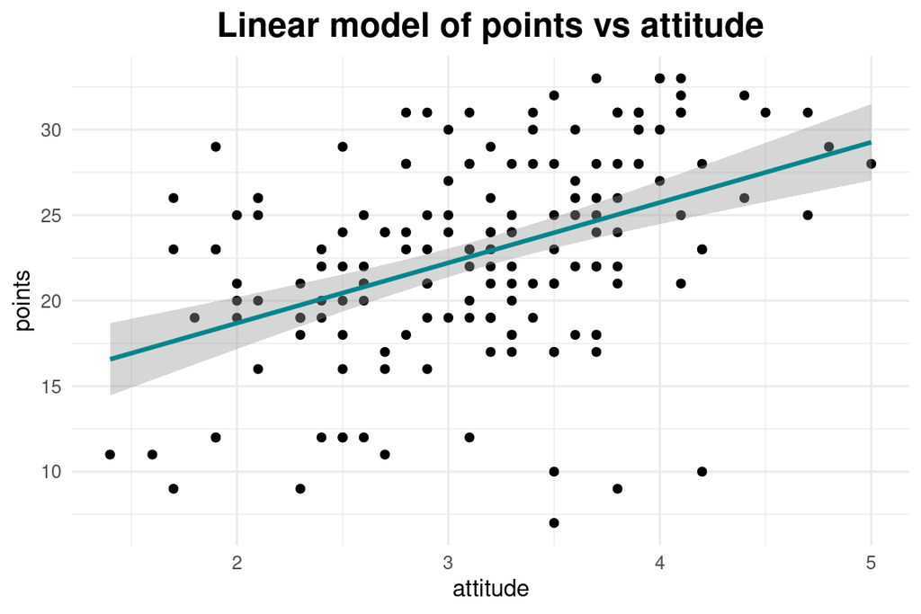

```r
# Access the gglot2 library
library(ggplot2)

# initialize plot with data and aesthetic mapping
p2 <- ggplot(learning2014, aes(x = attitude, y = points))

# define the visualization type (points)
p2 <- p2 + geom_point()

# plot the linear regression model
p2 <- p2 + geom_smooth(method='lm', color='turquoise4')

# change theme
p2 <- p2 + theme_minimal()

# add title
p2 <- p2 + labs(title="Linear model of points vs attitude")

# adjust title
p2 <- p2 + theme(plot.title = element_text(hjust=0.5, size=16, face='bold'))

# draw the plot
p2
```

## Interpretation of the fitted model

By removing the insignificant variables from the model, I obtain a fit with an even lower P-value. Seems like `attitude` affects `points` with a high statistical significance. On average, for each unit `attitude`, `points` increases by 3.5255 with a standard error of 0.5674. For vanishing `attitude` (an extrapolation to 0), the expected `points` is 11.6372 with a standard error of 1.8303. The multiple R-squared, which in this case with a single explanatory variable is simply the square of the correlation coefficient between `attitude` and `points`, is 0.1906, indicating that about 19% of the variation in `points` is explained by the variation in `attitude`. From this I can conclude that `attitude` has a significant impact on `points` but still the majority of the variance in `points` is explained by other factors not included in the data set.

## Diagnostic plots

Finally, I produce some diagnostic plots:

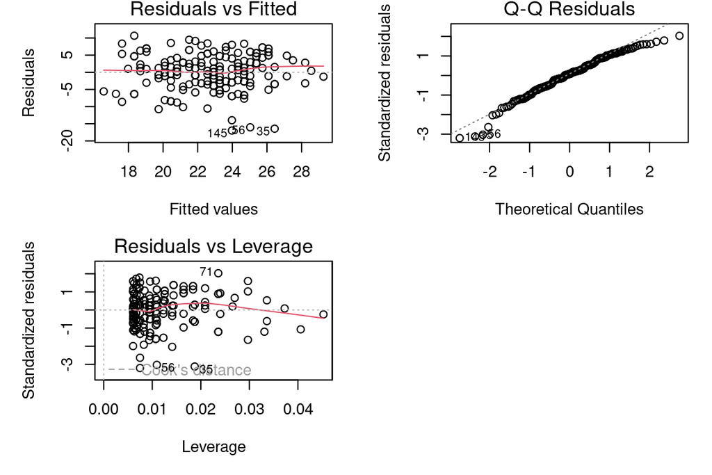

```r
# draw diagnostic plots using the plot() function. Choose the plots 1, 2 and 5
par(mfrow = c(2,2), mai=c(0.8,0.8,0.2,0.2), cex=0.8, pty="m")
plot(my_model2, which = c(1,2,5))
```

From the plots I can interpret that

- *Residuals vs Fitted*: Residuals seems to be centered around the model with an approximately constant variance so the assumptions of linearity and constant variance hold.
- *Q-Q Residuals*: The circles on the quantile-quantile plot line up fairly well on the theoretical line meaning that the assumption of normally distributed model residuals holds. The plot essentially compares the distribution of residuals from the data (circles) with the normal distribution of the model residuals (dashed line).
- *Residuals vs Leverage*: All the data points fall inside the Cook’s distance so there are not any influential points in the regression model. If there was an influential point, removing it from the data set would considerably change the coefficients of the model.

# Analysis of alcohol consumption data (Week 3)

In this Analysis exercise, I study an alcohol consumption data set by applying logistic regression.

## Loading the data

I start by loading the alcohol consumption data set with the `read_csv` function from the `readr` library and print the name of its variables:

```r
# load the readr library
library(readr)

# load the data file
alc <- read_csv("data/alc.csv")
# print the variable names
colnames(alc)
```

```
##  [1] "school"     "sex"        "age"        "address"    "famsize"
##  [6] "Pstatus"    "Medu"       "Fedu"       "Mjob"       "Fjob"
## [11] "reason"     "guardian"   "traveltime" "studytime"  "schoolsup"
## [16] "famsup"     "activities" "nursery"    "higher"     "internet"
## [21] "romantic"   "famrel"     "freetime"   "goout"      "Dalc"
## [26] "Walc"       "health"     "failures"   "paid"       "absences"
## [31] "G1"         "G2"         "G3"         "alc_use"    "high_use"
```

The data of 370 observations is combined from two data sets describing student achievement in secondary education of two Portuguese schools (https://archive.ics.uci.edu/dataset/320/student+performance). The data attributes include student grades, demographic, social and school related features and it was collected by using school reports and questionnaires. This analysis studies students’ alcohol consumption, which is described by four variables in the data:

- `Dalc`: Workday alcohol consumption (numeric: from 1 - very low to 5 - very high)
- `Walc`: Weekend alcohol consumption (numeric: from 1 - very low to 5 - very high)
- `alc_use`: Average of `Dalc` and `Walc`
- `high_use`: `TRUE` if `alc_use > 2` and `FALSE` otherwise

In this report, I will mostly focus on the last variable and its relationship with some of the other variables in the data set.

## Four variables vs. alcohol consumption

Next, I will choose four interesting variables and hypothesize about their relationship with high/low alcohol consumption. The variables and hypotheses are:

- `activities`: Extra-curricular activities (binary: `yes` or `no`). My guess is that students with extra-curricular activities have less time to consume alcohol.
- `freetime`: Free time after school (numeric: from `1` - very low to `5` - very high). My prediction is that the amount of free time a student has correlates with the alcohol consumption.
- `famrel`: Quality of family relationships (numeric: from `1` - very bad to `5` - excellent). I hypothesize that this variable has an anti-correlation with alcohol use: a high quality of family relationship promotes less drinking and vice versa.
- `studytime`: Weekly study time (numeric: `1` - <2 hours, `2` - 2 to 5 hours, `3` - 5 to 10 hours, or `4` - >10 hours). For this one, I also assume an anti-correlation: students who study more are less likely to have time and/or motivation to go out and drink.

Let’s study numerically and graphically the distributions of the chosen variables and see if the hypotheses hold. First, it is useful to check the distributions of each variable of interest:

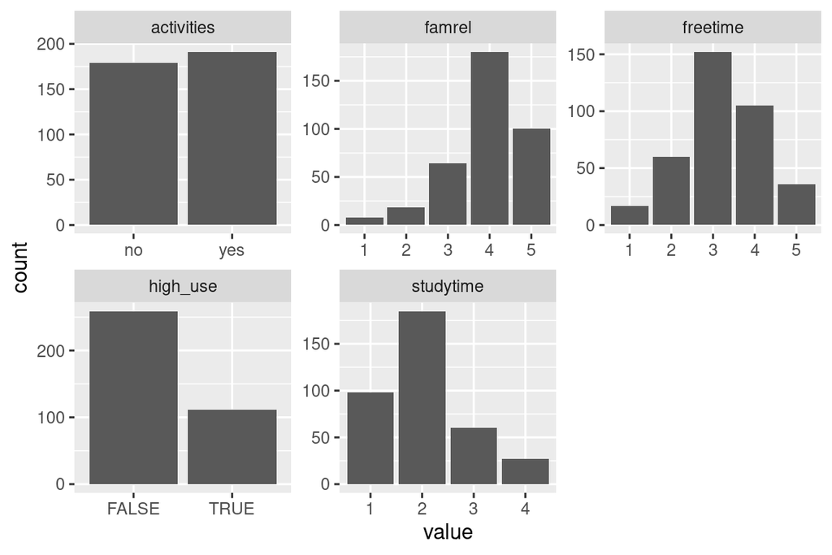

```r
# access the tidyverse libraries tidyr, dplyr, ggplot2
library(tidyr); library(dplyr); library(ggplot2)
# draw a bar plot of each variable
select(alc, all_of(c("high_use","activities","freetime","famrel","studytime"))) %>% gather %>% ggplot(aes(value)) + facet_wrap("key", scales = "free") + geom_bar()
```

It seems like almost third of the students are high users of alcohol. About half of them have extra-curricular activities, most of them have good family relations, and most study 2-5 hours a week. The `freetime` variable is not defined quantitatively, but most of the students consider to have intermediate amount of free time after school.

Next, some cross tabulations might reveal some relationships between the variables,

```r
# Cross tabulation of high alcohol use and activities
table(alc$high_use, alc$activities)
```

```
##
##          no yes
##   FALSE 120 139
##   TRUE   59  52
```

```r
# Cross tabulation of high alcohol use and free time
table(alc$high_use, alc$freetime)
```

```
##
##           1   2   3   4   5
##   FALSE  15  46 112  65  21
##   TRUE    2  14  40  40  15
```

```r
# Cross tabulation of high alcohol use and family relations
table(alc$high_use, alc$famrel)
```

```
##
##           1   2   3   4   5
##   FALSE   6   9  39 128  77
##   TRUE    2   9  25  52  23
```

```r
# Cross tabulation of high alcohol use and study time
table(alc$high_use, alc$studytime)
```

```
##
##           1   2   3   4
##   FALSE  56 128  52  23
##   TRUE   42  57   8   4
```

The same information presented graphically is perhaps easier to analyze,

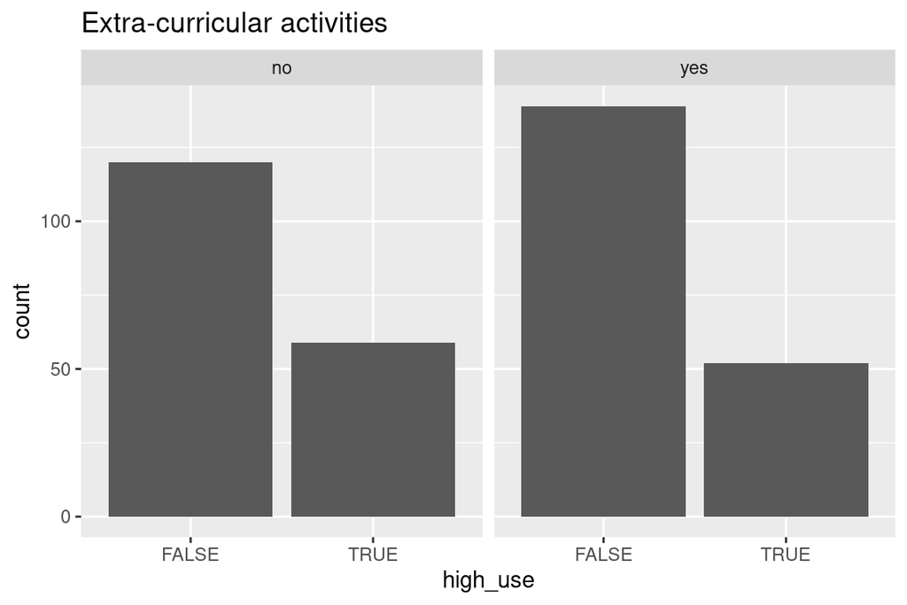

```r
# Plot high_use vs. activities
ggplot(data = alc, aes(x = high_use)) + geom_bar() + facet_wrap("activities") + ggtitle("Extra-curricular activities")
```

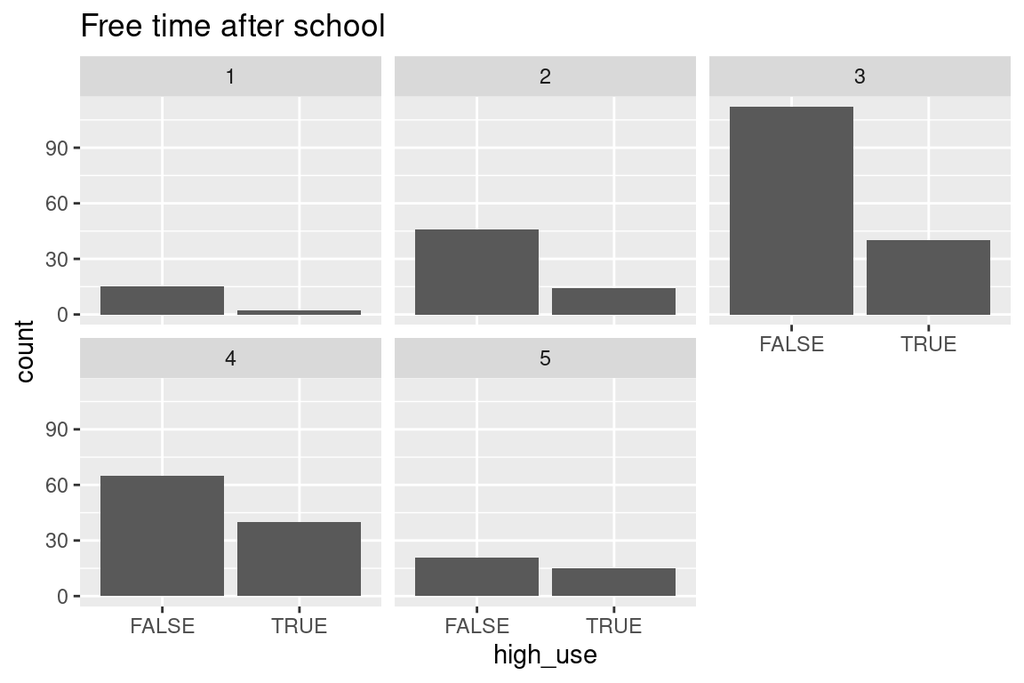

```r
# Plot high_use vs. freetime
ggplot(data = alc, aes(x = high_use)) + geom_bar() + facet_wrap("freetime") + ggtitle("Free time after school")
```

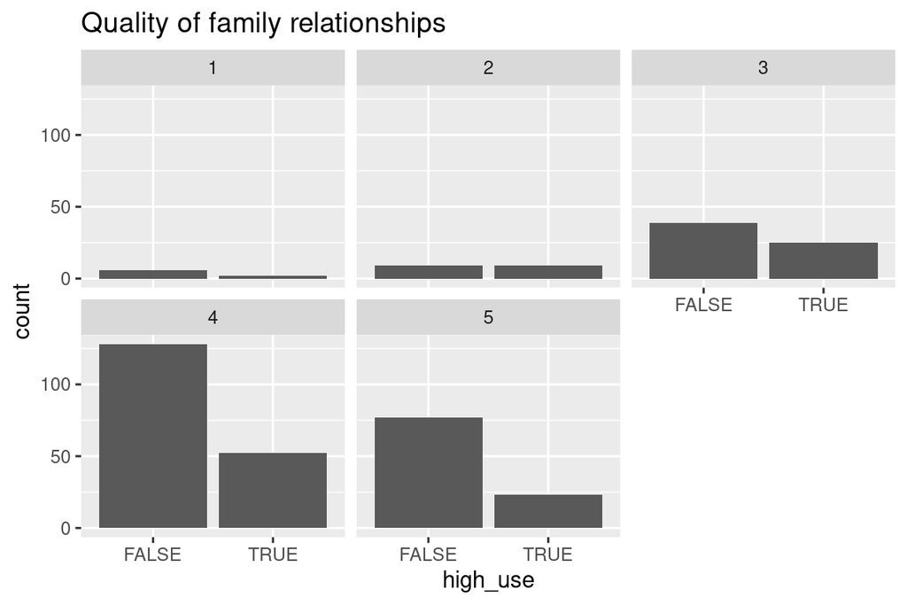

```r
# Plot high_use vs. famrel
ggplot(data = alc, aes(x = high_use)) + geom_bar() + facet_wrap("famrel") + ggtitle("Quality of family relationships")
```

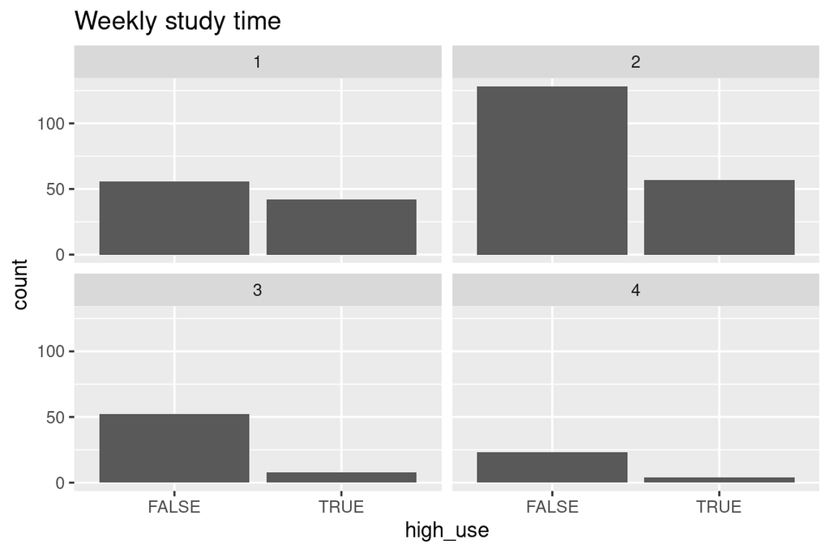

```r
# Plot high_use vs. studytime
ggplot(data = alc, aes(x = high_use)) + geom_bar() + facet_wrap("studytime") + ggtitle("Weekly study time")
```

In all of the four cases, the data seems to support my hypotheses at least by visually inspecting the distributions. Let’s approach the analysis more systematically and try to further solidify the hypotheses by using logistic regression to find statistically significant relationships between alcohol consumption (target variable) and the four chosen variables (predictors). Fitting a logistic regression model to the data yields

```r
# find the model with glm()
m <- glm(high_use ~ activities + freetime + famrel + studytime, data = alc, family = "binomial")

# print out a summary of the model
summary(m)
```

```
##
## Call:
## glm(formula = high_use ~ activities + freetime + famrel + studytime,
##     family = "binomial", data = alc)
##
## Coefficients:
##               Estimate Std. Error z value Pr(>|z|)
## (Intercept)     0.3793     0.6853   0.554 0.579899
## activitiesyes  -0.2363     0.2404  -0.983 0.325681
## freetime        0.3855     0.1267   3.042 0.002351 **
## famrel         -0.3365     0.1302  -2.584 0.009753 **
## studytime      -0.5460     0.1564  -3.491 0.000481 ***
## ---
## Signif. codes:  0 '***' 0.001 '**' 0.01 '*' 0.05 '.' 0.1 ' ' 1
##
## (Dispersion parameter for binomial family taken to be 1)
##
##     Null deviance: 452.04  on 369  degrees of freedom
## Residual deviance: 418.92  on 365  degrees of freedom
## AIC: 428.92
##
## Number of Fisher Scoring iterations: 4
```

From the coefficients of the model, describing the logarithms of odds ratios, I can already observe the hypothesized (anti-)correlation pattern. In the case of `activities` (with reference class `no`), the error of the estimate is, however, very large resulting in insignificant relationship with high alcohol use. For the other three variables, the relationship is much stronger, especially with `studytime`. The P-values of the fitted model tell the same story. Let’s study the coefficients in a bit more detail by computing the odds ratios (OR) and their 95% confidence intervals (CI). The former is obtained simply by exponentiating the above coefficients and the latter is given by the `confint` function,

```r
# compute odds ratios (OR)
OR <- coef(m) %>% exp

# compute confidence intervals (CI)
CI <- confint(m) %>% exp
# print out the odds ratios with their confidence intervals
cbind(OR, CI)
```

```
##                      OR     2.5 %    97.5 %
## (Intercept)   1.4612807 0.3790614 5.6153890
## activitiesyes 0.7895289 0.4919076 1.2645821
## freetime      1.4703933 1.1513380 1.8944541
## famrel        0.7142510 0.5521613 0.9215397
## studytime     0.5792716 0.4222494 0.7807407
```

The odds ratios and their confidence intervals have a clear interpretation. For `activities`, the odds ratio for having high alcohol use when having extra-curricular activities (vs. not having activities) is 0.79 with a 95% CI of [0.49,1.26]. As this interval contains the value 1 (1 means equal odds for `high_use` in both values of `activities`), I can conclude that there is no evidence of an association between `activities` and `high_use`. For `freetime`, the interpretation is that when `freetime` is increased by 1 unit, the odds ratio for `high_use` becomes 1.47 with CI of [1.15, 1.89]. In this case, the interval does not contain 1 so we can safely say that there is a statistically meaningful correlation between `freetime` and `high_use`. The same conclusion can be drawn for `famrel` and `studytime`, where I observe significant anticorrelation. As already hinted by the coefficients of the model, the conclusion is that `activities` is an irrelevant variable when considering `high_use` and the three other variables have a significant impact on `high_use`.

## Testing predictions

Using the three statistically significant variables `freetime`, `famrel`, and `studytime` for the target variable `high_use`, I can explore the predictive power of the model. Computing the probability of `high_use` given the three variables and obtaining the resulting predictions (>0.5 = `TRUE`) yields a cross tabulation

```r
# fit the model
m2 <- glm(high_use ~ freetime + famrel + studytime, data = alc, family = "binomial")

# predict() the probability of high_use
probabilities <- predict(m2, type = "response")

# add the predicted probabilities to 'alc'
alc <- mutate(alc, probability = probabilities)

# use the probabilities to make a prediction of high_use
alc <- mutate(alc, prediction = probability > 0.5)

# tabulate the target variable versus the predictions
table(Actual = alc$high_use, Predicted = alc$prediction) %>% prop.table() %>% addmargins()
```

```
##        Predicted
## Actual       FALSE       TRUE        Sum
##   FALSE 0.65675676 0.04324324 0.70000000
##   TRUE  0.26756757 0.03243243 0.30000000
##   Sum   0.92432432 0.07567568 1.00000000
```

which can be plotted

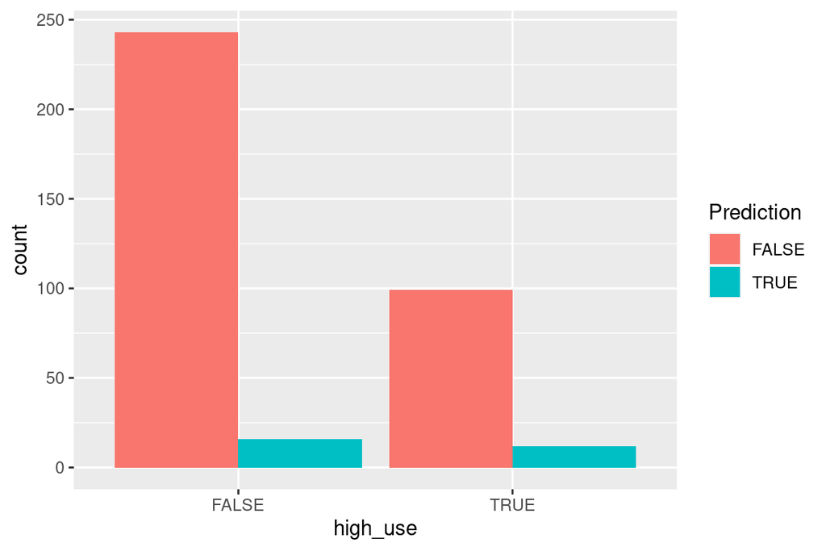

```r
# plot of the cross tabulation
ggplot(alc, aes(x = high_use, fill = as.factor(prediction))) + geom_bar(position = "dodge") + labs(fill = "Prediction")
```

As seen from the table and plot, the model is quite good for predicting the `FALSE` case: 66% of all cases are predicted correctly as `FALSE` (cf. the actual 70%). However, the `TRUE` case is poorly predicted due to false negatives, as majority of actual high users are classified as low users. Only 3% of all cases `TRUE` cases are predicted correctly as the actual percentage is 30%. The proportion of false negatives is 27% and false positives 4%. The model seems to have a strong bias towards low users of alcohol and this is probably due to not including some other more important variables to the model. With this clearly incomplete model, the training error (the proportion of inaccurately classified cases) is

```r
# training error
model_error <- mean(alc$high_use != alc$prediction)

# print error
model_error
```

```
## [1] 0.3108108
```

Given the above results, it is not surprising that the error is very high. It is even worse than the error resulting by guessing that all of the students are low users of alcohol (as that’s the most frequent case) which is 30%. The high error is explained by the large proportion of false negatives in the predictions.

## Cross-validation (bonus)

Finally, I will perform a 10-fold cross-validation on the model. By defining the loss function `loss_func`, I can use the `cv.glm` function from `boot` library to perform the cross-validation,

```r
# define a loss function (average prediction error)
loss_func <- function(class, prob) {
  n_wrong <- abs(class - prob) > 0.5
  mean(n_wrong)
}

# load boot library
library(boot)

# set seed for reproducibility
set.seed(1234)

# K-fold cross-validation
cv <- cv.glm(data = alc, cost = loss_func, glmfit = m2, K = 10)

# average number of wrong predictions in the cross validation
cv$delta[1]
```

```
## [1] 0.3081081
```

The resulting mean prediction error is 31%, i.e. the same as without the cross-validation. This large error reflects the fact that the model is incomplete. The test performance of this model is worse compared to the one introduced in the Exercise Set, but I manage to find a model that out-performs it. Namely, by considering the variables `sex`, `goout`, and `absences`, I obtain the model

```r
# fit the model
m3 <- glm(high_use ~ sex + goout + absences, data = alc, family = "binomial")

# print out summary
summary(m3)
```

```
##
## Call:
## glm(formula = high_use ~ sex + goout + absences, family = "binomial",
##     data = alc)
##
## Coefficients:
##             Estimate Std. Error z value Pr(>|z|)
## (Intercept) -4.18142    0.48085  -8.696  < 2e-16 ***
## sexM         1.02223    0.25946   3.940 8.15e-05 ***
## goout        0.72793    0.12057   6.038 1.56e-09 ***
## absences     0.08478    0.02266   3.741 0.000183 ***
## ---
## Signif. codes:  0 '***' 0.001 '**' 0.01 '*' 0.05 '.' 0.1 ' ' 1
##
## (Dispersion parameter for binomial family taken to be 1)
##
##     Null deviance: 452.04  on 369  degrees of freedom
## Residual deviance: 374.10  on 366  degrees of freedom
## AIC: 382.1
##
## Number of Fisher Scoring iterations: 4
```

```r
# set seed for reproducibility
set.seed(1234)

# K-fold cross-validation
cv.glm(data = alc, cost = loss_func, glmfit = m3, K = 10)$delta[1]
```

```
## [1] 0.2135135
```

which has a prediction error of 21%.

# Clustering and classification of Boston data set (Week 4)

In this Analysis exercise, I study the Boston set from the MASS package mostly focusing on crime rates in suburbs of Boston.

## Loading the data

First, I load the Boston data set from the MASS package and explore its structure and dimensions,

```r
# access the MASS package
library(MASS)
# load the data
data("Boston")

# explore the dataset
str(Boston)
```

```
## 'data.frame':    506 obs. of  14 variables:
##  $ crim   : num  0.00632 0.02731 0.02729 0.03237 0.06905 ...
##  $ zn     : num  18 0 0 0 0 0 12.5 12.5 12.5 12.5 ...
##  $ indus  : num  2.31 7.07 7.07 2.18 2.18 2.18 7.87 7.87 7.87 7.87 ...
##  $ chas   : int  0 0 0 0 0 0 0 0 0 0 ...
##  $ nox    : num  0.538 0.469 0.469 0.458 0.458 0.458 0.524 0.524 0.524 0.524 ...
##  $ rm     : num  6.58 6.42 7.18 7 7.15 ...
##  $ age    : num  65.2 78.9 61.1 45.8 54.2 58.7 66.6 96.1 100 85.9 ...
##  $ dis    : num  4.09 4.97 4.97 6.06 6.06 ...
##  $ rad    : int  1 2 2 3 3 3 5 5 5 5 ...
##  $ tax    : num  296 242 242 222 222 222 311 311 311 311 ...
##  $ ptratio: num  15.3 17.8 17.8 18.7 18.7 18.7 15.2 15.2 15.2 15.2 ...
##  $ black  : num  397 397 393 395 397 ...
##  $ lstat  : num  4.98 9.14 4.03 2.94 5.33 ...
##  $ medv   : num  24 21.6 34.7 33.4 36.2 28.7 22.9 27.1 16.5 18.9 ...
```

There are 506 observations and 14 numeric variables that are related to housing in suburbs of Boston:

- `crim`: per capita crime rate by town,
- `zn`: proportion of residential land zoned for lots over 25,000 sq.ft.,
- `indus`: proportion of non-retail business acres per town,
- `chas`: Charles River dummy variable (= 1 if tract bounds river; 0 otherwise),
- `nox`: nitrogen oxides concentration (parts per 10 million),
- `rm`: average number of rooms per dwelling,
- `age`: proportion of owner-occupied units built prior to 1940,
- `dis`: weighted mean of distances to five Boston employment centres,
- `rad`: index of accessibility to radial highways,
- `tax`: full-value property-tax rate per $10,000,
- `ptratio`: pupil-teacher ratio by town,
- `black`: $1000(Bk−0.63)^2$ $Bk$ is the proportion of blacks by town,
- `lstat`: lower status of the population (percent),
- `medv`: median value of owner-occupied homes in $1000s.

## Graphical overview of the data

Next, I give a visual representation of the distributions of the different variables and correlations between them. Let’s start by summarizing the variables,

```r
# print out the summary of the variables
summary(Boston)
```

```
##       crim                zn             indus            chas
##  Min.   : 0.00632   Min.   :  0.00   Min.   : 0.46   Min.   :0.00000
##  1st Qu.: 0.08205   1st Qu.:  0.00   1st Qu.: 5.19   1st Qu.:0.00000
##  Median : 0.25651   Median :  0.00   Median : 9.69   Median :0.00000
##  Mean   : 3.61352   Mean   : 11.36   Mean   :11.14   Mean   :0.06917
##  3rd Qu.: 3.67708   3rd Qu.: 12.50   3rd Qu.:18.10   3rd Qu.:0.00000
##  Max.   :88.97620   Max.   :100.00   Max.   :27.74   Max.   :1.00000
##       nox               rm             age              dis
##  Min.   :0.3850   Min.   :3.561   Min.   :  2.90   Min.   : 1.130
##  1st Qu.:0.4490   1st Qu.:5.886   1st Qu.: 45.02   1st Qu.: 2.100
##  Median :0.5380   Median :6.208   Median : 77.50   Median : 3.207
##  Mean   :0.5547   Mean   :6.285   Mean   : 68.57   Mean   : 3.795
##  3rd Qu.:0.6240   3rd Qu.:6.623   3rd Qu.: 94.08   3rd Qu.: 5.188
##  Max.   :0.8710   Max.   :8.780   Max.   :100.00   Max.   :12.127
##       rad              tax           ptratio          black
##  Min.   : 1.000   Min.   :187.0   Min.   :12.60   Min.   :  0.32
##  1st Qu.: 4.000   1st Qu.:279.0   1st Qu.:17.40   1st Qu.:375.38
##  Median : 5.000   Median :330.0   Median :19.05   Median :391.44
##  Mean   : 9.549   Mean   :408.2   Mean   :18.46   Mean   :356.67
##  3rd Qu.:24.000   3rd Qu.:666.0   3rd Qu.:20.20   3rd Qu.:396.23
##  Max.   :24.000   Max.   :711.0   Max.   :22.00   Max.   :396.90
##      lstat            medv
##  Min.   : 1.73   Min.   : 5.00
##  1st Qu.: 6.95   1st Qu.:17.02
##  Median :11.36   Median :21.20
##  Mean   :12.65   Mean   :22.53
##  3rd Qu.:16.95   3rd Qu.:25.00
##  Max.   :37.97   Max.   :50.00
```

A more visual way to study the distributions of the variables is to draw density plots,

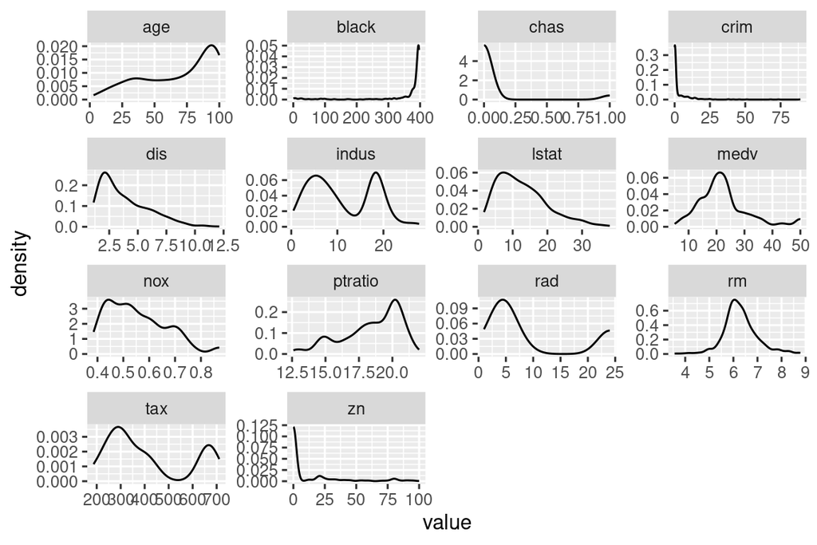

```r
# access the tidyverse libraries tidyr, dplyr, ggplot2
library(tidyr); library(dplyr); library(ggplot2);

# plot the distributions as densities
Boston %>% gather %>% ggplot(aes(value)) + facet_wrap("key", scales = "free") + geom_density()
```

In the distribution plots, I can see that at least the distribution of `rm` is somewhat normally distributed, while the others are far from a normal distribution. Most of the distributions are positively skewed: `chas`, `crim`, `dis`, `lstat`, `medv`, `nox`, and `zn`. On the other hand, `age` and `black` are negatively skewed. Further, three distributions have double peaks: `indus`, `rad`, and `tax`.

Now that we know how the variables are distributed, let’s consider the correlations between them and create a correlation matrix by using the function `cor` and rounding the resulting numbers to 2-decimal precision:

```r
# calculate the correlation matrix and round it
cor_matrix <- cor(Boston) %>% round(2)

# print the correlation matrix
cor_matrix
```

```
##          crim    zn indus  chas   nox    rm   age   dis   rad   tax ptratio
## crim     1.00 -0.20  0.41 -0.06  0.42 -0.22  0.35 -0.38  0.63  0.58    0.29
## zn      -0.20  1.00 -0.53 -0.04 -0.52  0.31 -0.57  0.66 -0.31 -0.31   -0.39
## indus    0.41 -0.53  1.00  0.06  0.76 -0.39  0.64 -0.71  0.60  0.72    0.38
## chas    -0.06 -0.04  0.06  1.00  0.09  0.09  0.09 -0.10 -0.01 -0.04   -0.12
## nox      0.42 -0.52  0.76  0.09  1.00 -0.30  0.73 -0.77  0.61  0.67    0.19
## rm      -0.22  0.31 -0.39  0.09 -0.30  1.00 -0.24  0.21 -0.21 -0.29   -0.36
## age      0.35 -0.57  0.64  0.09  0.73 -0.24  1.00 -0.75  0.46  0.51    0.26
## dis     -0.38  0.66 -0.71 -0.10 -0.77  0.21 -0.75  1.00 -0.49 -0.53   -0.23
## rad      0.63 -0.31  0.60 -0.01  0.61 -0.21  0.46 -0.49  1.00  0.91    0.46
## tax      0.58 -0.31  0.72 -0.04  0.67 -0.29  0.51 -0.53  0.91  1.00    0.46
## ptratio  0.29 -0.39  0.38 -0.12  0.19 -0.36  0.26 -0.23  0.46  0.46    1.00
## black   -0.39  0.18 -0.36  0.05 -0.38  0.13 -0.27  0.29 -0.44 -0.44   -0.18
## lstat    0.46 -0.41  0.60 -0.05  0.59 -0.61  0.60 -0.50  0.49  0.54    0.37
## medv    -0.39  0.36 -0.48  0.18 -0.43  0.70 -0.38  0.25 -0.38 -0.47   -0.51
##         black lstat  medv
## crim    -0.39  0.46 -0.39
## zn       0.18 -0.41  0.36
## indus   -0.36  0.60 -0.48
## chas     0.05 -0.05  0.18
## nox     -0.38  0.59 -0.43
## rm       0.13 -0.61  0.70
## age     -0.27  0.60 -0.38
## dis      0.29 -0.50  0.25
## rad     -0.44  0.49 -0.38
## tax     -0.44  0.54 -0.47
## ptratio -0.18  0.37 -0.51
## black    1.00 -0.37  0.33
## lstat   -0.37  1.00 -0.74
## medv     0.33 -0.74  1.00
```

To illustrate the correlations between the variables in a more visual manner, I plot the above matrix using the `corrplot` function from the `corrplot` library,

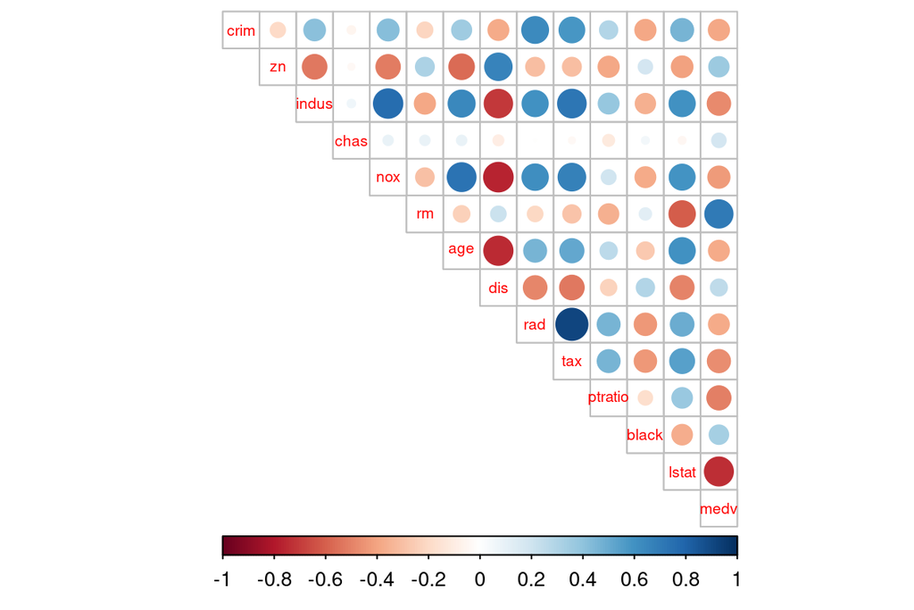

```r
# visualize the correlation matrix
library(corrplot)
corrplot(cor_matrix, method="circle", type="upper", cl.pos="b", tl.pos = "d", tl.cex=0.6)
```

As seen in the correlation plot, `rad` and `tax` have the strongest correlation, which indicates that properties that have a good access to radial highways have higher tax rates. Second highest correlation is between `indus` and `nox`, which makes sense since industry might produce nitrogen oxides. The strongest anti-correlation, however, is between `dis` and `nox` indicating that there are less nitrogen oxides at residences further away from the employment centers. The second highest anti-correlation is between `age` and `dis` meaning that residences near employment centers are typically older.

## Creating train and test sets

Next, I create train and test sets for studying the `crim` variable. First, I standardize the data set using the `scale` function which subtracts the column means from the corresponding columns and divides the difference with standard deviation, i.e.

$$\text{scaled}(X) = \frac{X-\text{mean}(X)}{\text{sd}(X)}.$$

Scaling the variables and printing out the summaries yields

```r
# center and standardize variables
boston_scaled <- Boston %>% scale

# summaries of the scaled variables
boston_scaled %>% summary
```

```
##       crim                 zn               indus              chas
##  Min.   :-0.419367   Min.   :-0.48724   Min.   :-1.5563   Min.   :-0.2723
##  1st Qu.:-0.410563   1st Qu.:-0.48724   1st Qu.:-0.8668   1st Qu.:-0.2723
##  Median :-0.390280   Median :-0.48724   Median :-0.2109   Median :-0.2723
##  Mean   : 0.000000   Mean   : 0.00000   Mean   : 0.0000   Mean   : 0.0000
##  3rd Qu.: 0.007389   3rd Qu.: 0.04872   3rd Qu.: 1.0150   3rd Qu.:-0.2723
##  Max.   : 9.924110   Max.   : 3.80047   Max.   : 2.4202   Max.   : 3.6648
##       nox                rm               age               dis
##  Min.   :-1.4644   Min.   :-3.8764   Min.   :-2.3331   Min.   :-1.2658
##  1st Qu.:-0.9121   1st Qu.:-0.5681   1st Qu.:-0.8366   1st Qu.:-0.8049
##  Median :-0.1441   Median :-0.1084   Median : 0.3171   Median :-0.2790
##  Mean   : 0.0000   Mean   : 0.0000   Mean   : 0.0000   Mean   : 0.0000
##  3rd Qu.: 0.5981   3rd Qu.: 0.4823   3rd Qu.: 0.9059   3rd Qu.: 0.6617
##  Max.   : 2.7296   Max.   : 3.5515   Max.   : 1.1164   Max.   : 3.9566
##       rad               tax             ptratio            black
##  Min.   :-0.9819   Min.   :-1.3127   Min.   :-2.7047   Min.   :-3.9033
##  1st Qu.:-0.6373   1st Qu.:-0.7668   1st Qu.:-0.4876   1st Qu.: 0.2049
##  Median :-0.5225   Median :-0.4642   Median : 0.2746   Median : 0.3808
##  Mean   : 0.0000   Mean   : 0.0000   Mean   : 0.0000   Mean   : 0.0000
##  3rd Qu.: 1.6596   3rd Qu.: 1.5294   3rd Qu.: 0.8058   3rd Qu.: 0.4332
##  Max.   : 1.6596   Max.   : 1.7964   Max.   : 1.6372   Max.   : 0.4406
##      lstat              medv
##  Min.   :-1.5296   Min.   :-1.9063
##  1st Qu.:-0.7986   1st Qu.:-0.5989
##  Median :-0.1811   Median :-0.1449
##  Mean   : 0.0000   Mean   : 0.0000
##  3rd Qu.: 0.6024   3rd Qu.: 0.2683
##  Max.   : 3.5453   Max.   : 2.9865
```

```r
# class of the boston_scaled object
class(boston_scaled)
```

```
## [1] "matrix" "array"
```

```r
# change the object to data frame
boston_scaled <- as.data.frame(boston_scaled)
```

To proceed, I create a categorical variable `crime` from the variable `crim` using the quantiles as the break points. Then I remove `crim` from the data set and add there the new categorical variable `crime`,

```r
# create a quantile vector of crim and print it
bins <- quantile(boston_scaled$crim)
bins
```

```
##           0%          25%          50%          75%         100%
## -0.419366929 -0.410563278 -0.390280295  0.007389247  9.924109610
```

```r
# create a categorical variable 'crime'
crime <- cut(boston_scaled$crim, breaks = bins, include.lowest = TRUE, label = c("low", "med_low", "med_high", "high"))

# look at the table of the new factor crime
table(crime)
```

```
## crime
##      low  med_low med_high     high
##      127      126      126      127
```

```r
# remove original crim from the dataset
boston_scaled <- dplyr::select(boston_scaled, -crim)

# add the new categorical value to scaled data
boston_scaled <- data.frame(boston_scaled, crime)
```

Finally, I divide the data set into train and test sets sot that 80% of the data belongs to the train set,

```r
# number of rows in the Boston dataset
n <- nrow(boston_scaled)

# fix the seed for reproducibility
set.seed(12321)

# choose randomly 80% of the rows
ind <- sample(n,  size = n * 0.8)

# create train set
train <- boston_scaled[ind,]

# create test set
test <- boston_scaled[-ind,]
```

## Fitting the LDA model

Next, I fit a linear discriminant analysis (LDA) model to the train set using `crime` as the target variable and all the other variables as predictors. The model finds the (linear) combination of the variables that separate the four classes of `crime`. The result of the fit is

```r
# linear discriminant analysis
lda.fit <- lda(crime ~ ., data = train)

# print the lda.fit object
lda.fit
```

```
## Call:
## lda(crime ~ ., data = train)
##
## Prior probabilities of groups:
##       low   med_low  med_high      high
## 0.2475248 0.2400990 0.2648515 0.2475248
##
## Group means:
##                  zn      indus         chas        nox         rm        age
## low       0.9437842 -0.8977495 -0.114845058 -0.8756394  0.4414575 -0.8623404
## med_low  -0.1084185 -0.2764991  0.011791568 -0.5528778 -0.1395891 -0.2610442
## med_high -0.3654210  0.1583590  0.242805543  0.3999245  0.1665618  0.3540541
## high     -0.4872402  1.0171519  0.003267949  1.1083666 -0.4254869  0.8137487
##                 dis        rad        tax     ptratio      black       lstat
## low       0.8903919 -0.6867152 -0.7459316 -0.41457560  0.3882657 -0.77496367
## med_low   0.3413025 -0.5556360 -0.5111911 -0.02231793  0.3158068 -0.10597508
## med_high -0.3724189 -0.3893910 -0.3042329 -0.35761878  0.1122724 -0.04224321
## high     -0.8575134  1.6377820  1.5138081  0.78037363 -0.7962215  0.88438347
##                  medv
## low       0.532906188
## med_low   0.001252957
## med_high  0.249560192
## high     -0.738689729
##
## Coefficients of linear discriminants:
##                 LD1          LD2         LD3
## zn       0.13849407  0.811336407 -0.84916150
## indus   -0.01049539 -0.110211684  0.27066791
## chas    -0.06471987 -0.080022418  0.13356753
## nox      0.40707035 -0.719501411 -1.42064698
## rm      -0.09593902 -0.078873876 -0.17987919
## age      0.25056541 -0.224804289  0.07174938
## dis     -0.11780950 -0.237475663  0.21149550
## rad      2.96814349  1.112608968 -0.10344537
## tax      0.02030172 -0.330852182  0.52109265
## ptratio  0.13023807  0.070820115 -0.20502516
## black   -0.13867511 -0.008657768  0.07079934
## lstat    0.23192966 -0.257595151  0.40662470
## medv     0.20888095 -0.399812637 -0.19088121
##
## Proportion of trace:
##    LD1    LD2    LD3
## 0.9448 0.0411 0.0141
```

The resulting LDA model can be plotted as a biplot by first creating a function for `lda.arrows` and then plotting `lda.fit` with the created arrows,

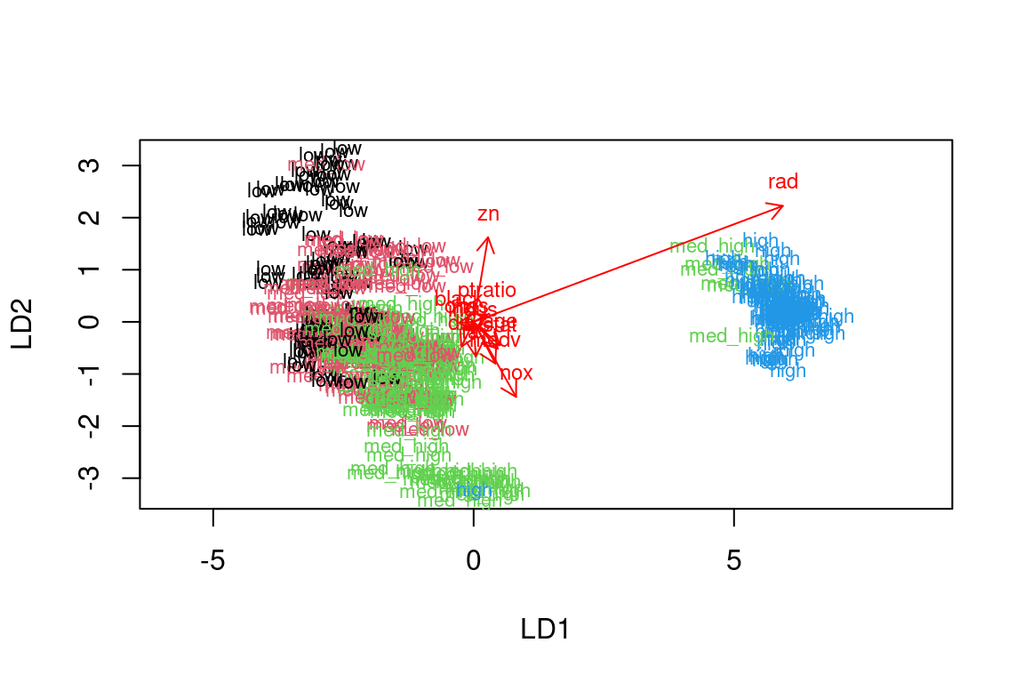

```r
# the function for lda biplot arrows
lda.arrows <- function(x, myscale = 1, arrow_heads = 0.1, color = "red", tex = 0.75, choices = c(1,2)){
  heads <- coef(x)
  graphics::arrows(x0 = 0, y0 = 0,
         x1 = myscale * heads[,choices[1]],
         y1 = myscale * heads[,choices[2]], col=color, length = arrow_heads)
  text(myscale * heads[,choices], labels = row.names(heads),
       cex = tex, col=color, pos=3)
}

# target classes as numeric
classes <- as.numeric(train$crime)

# plot the lda results (select both lines and execute them at the same time!)
plot(lda.fit, dimen = 2, col = classes, pch = classes)
lda.arrows(lda.fit, myscale = 2)
```

## Predicting with the LDA model

Now that I have the LDA model, I can use it to predict crime rates from the other variables. To do that, I first save and remove the correct crime categories from the test set,

```r
# save the correct classes from test data
correct_classes <- test$crime

# remove the crime variable from test data
test <- dplyr::select(test, -crime)
```

Now, I can use `lda.pred` to predict the categorical crime rates of the test set and cross-tabulate the predicted results with the correct crime rates that I just saved,

```r
# predict classes with test data
lda.pred <- predict(lda.fit, newdata = test)

# cross tabulate the results
table(correct = correct_classes, predicted = lda.pred$class)
```

```
##           predicted
## correct    low med_low med_high high
##   low       17       8        2    0
##   med_low    8      16        5    0
##   med_high   0       8       11    0
##   high       0       0        0   27
```

It seems like the LDA predicts the `high` category flawlessly but with the other three categories there are some mispredictions indicated by the nonzero off-diagonal components. However, the largest values are on the diagonal, which indicates that the model is performing somewhat well.

## K-means clustering

As a final task, I apply the K-means clustering algorithm to the Boston data set in order to group similar observations into clusters. The (Euclidean) distances between the observations are

```r
# reload Boston data set
data("Boston")

# center and standardize variables
boston_scaled2 <- Boston %>% scale

# euclidean distance matrix
dist_eu <- dist(boston_scaled2)

# look at the summary of the distances
summary(dist_eu)
```

```
##    Min. 1st Qu.  Median    Mean 3rd Qu.    Max.
##  0.1343  3.4625  4.8241  4.9111  6.1863 14.3970
```

The K-means clustering can be obtained with the function `kmeans` which actually computes the distances automatically. To determine an optimal value for the number of clusters, I look at how the total of within cluster sum of squares (WCSS) behaves when the number of clusters changes. For the optimal number of clusters, the total WCSS drops radically as a function of the number of clusters. Computing the total WCSS and plotting the result as a function of the number of clusters yields

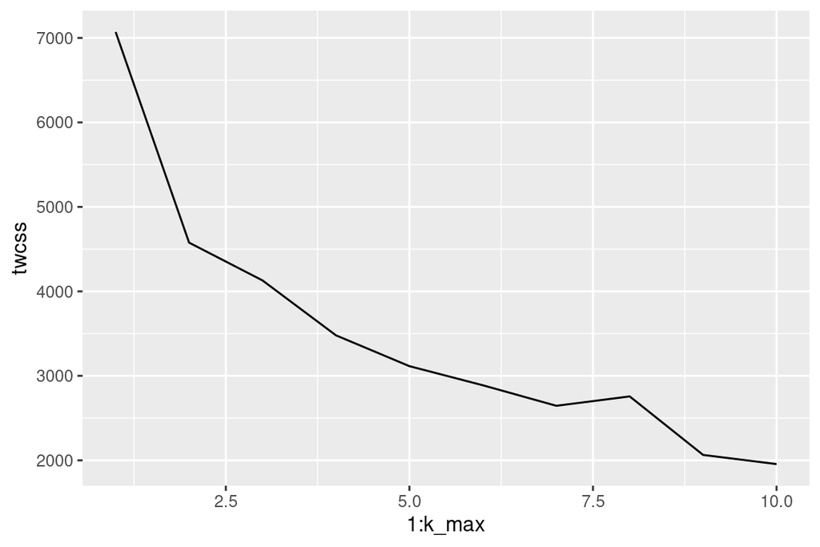

```r
# set seed for reproducibility
set.seed(1334)

# determine the maximum number of clusters
k_max <- 10

# calculate the total within sum of squares
twcss <- sapply(1:k_max, function(k){kmeans(boston_scaled2, k)$tot.withinss})

# visualize the results
qplot(x = 1:k_max, y = twcss, geom = 'line')
```

From the plot I can see that the optimal number of clusters could be two in this case. Also seven could be an optimal value but I choose two since the drop is the steepest when coming from one to two. Using two clusters, the k-means clustering yields

```r
# k-means clustering
km <- kmeans(boston_scaled2, centers = 2)
```

Now I can plot the result of the clustering using `pairs` and use different colors for the two clusters. I focus on five variables that are related to the crime rates according to the previous analysis: `crim`, `rad`, `nox`, `zn`, and `medv`,

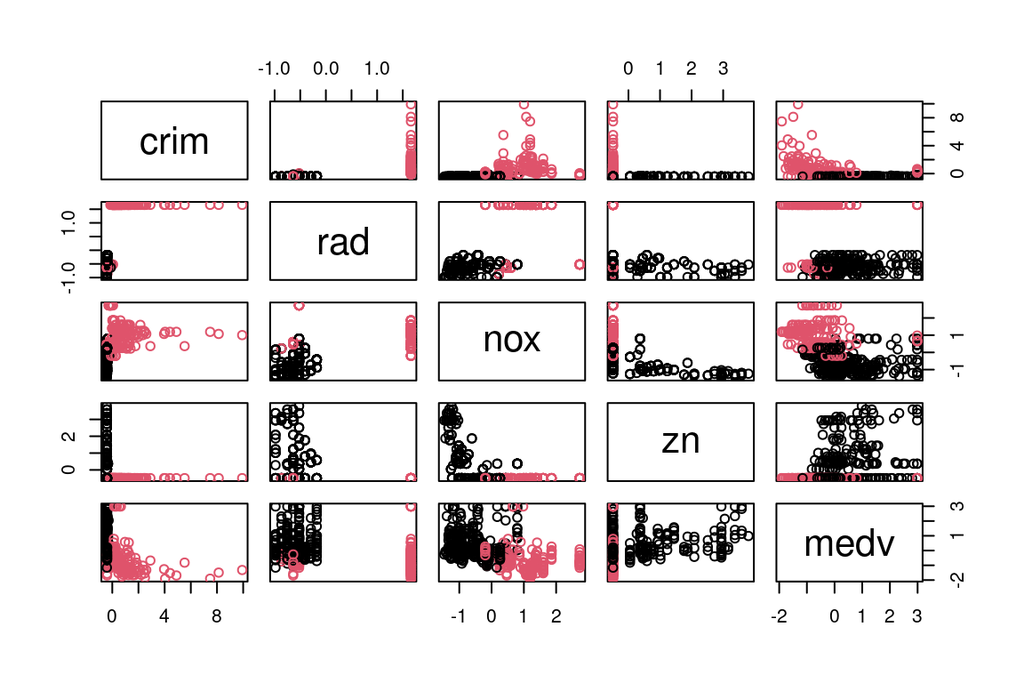

```r
# change the object to data frame
boston_scaled2 <- as.data.frame(boston_scaled2)

# plot the Boston dataset with clusters
pairs(boston_scaled2[c("crim", "rad", "nox", "zn", "medv")], col = km$cluster)
```

Looking at the plot, I observe that the clustering is visible in many pairs of variables. This is especially true with pairs including `crim` probably because the four other variables play a major role when classifying the crime rates as we saw in the previous analysis.

# Dimensionality reduction techniques (Week 5)

In this Analysis exercise, I analyze two data sets with dimensionality reduction techniques. The first data set describes peoples’ well being in different countries and the second one tea consumption.

## Loading the data

First, I load the human data set and explore its structure and dimensions,

```r
# load libraries
library(dplyr)
library(readr)

# load the data
human <- read_csv("data/human.csv")
# print out structure and dimenstions
str(human)
```

```
## spc_tbl_ [155 × 9] (S3: spec_tbl_df/tbl_df/tbl/data.frame)
##  $ Country  : chr [1:155] "Norway" "Australia" "Switzerland" "Denmark" ...
##  $ Edu2.FM  : num [1:155] 1.007 0.997 0.983 0.989 0.969 ...
##  $ Labo.FM  : num [1:155] 0.891 0.819 0.825 0.884 0.829 ...
##  $ Life.Exp : num [1:155] 81.6 82.4 83 80.2 81.6 80.9 80.9 79.1 82 81.8 ...
##  $ Edu.Exp  : num [1:155] 17.5 20.2 15.8 18.7 17.9 16.5 18.6 16.5 15.9 19.2 ...
##  $ GNI      : num [1:155] 64992 42261 56431 44025 45435 ...
##  $ Mat.Mor  : num [1:155] 4 6 6 5 6 7 9 28 11 8 ...
##  $ Ado.Birth: num [1:155] 7.8 12.1 1.9 5.1 6.2 3.8 8.2 31 14.5 25.3 ...
##  $ Parli.F  : num [1:155] 39.6 30.5 28.5 38 36.9 36.9 19.9 19.4 28.2 31.4 ...
##  - attr(*, "spec")=
##   .. cols(
##   ..   Country = col_character(),
##   ..   Edu2.FM = col_double(),
##   ..   Labo.FM = col_double(),
##   ..   Life.Exp = col_double(),
##   ..   Edu.Exp = col_double(),
##   ..   GNI = col_double(),
##   ..   Mat.Mor = col_double(),
##   ..   Ado.Birth = col_double(),
##   ..   Parli.F = col_double()
##   .. )
##  - attr(*, "problems")=<externalptr>
```

The data combines several indicators from most countries in the world. The variables are

- `Country`: Country name,
- `Edu2.FM`: Ratio of proportions of females and males with at least secondary education,
- `Labo.FM`: Ratio of proportions of females and males in the labour force,
- `Life.Exp`: Life expectancy at birth,
- `Edu.Exp`: Expected years of schooling,
- `GNI`: Gross National Income per capita,
- `Mat.Mor`: Maternal mortality ratio,
- `Ado.Birth`: Adolescent birth rate,
- `Parli.F`: Percetange of female representatives in parliament.

## Inspecting the data

Let’s begin by inspecting the data set. First I am going to mode the country names to row names,

```r
# move the country names to row names
library(tibble)
human <- column_to_rownames(human, "Country")
```

and then print out the summaries of the variables,

```r
# print out summaries
summary(human)
```

```
##     Edu2.FM          Labo.FM          Life.Exp        Edu.Exp
##  Min.   :0.1717   Min.   :0.1857   Min.   :49.00   Min.   : 5.40
##  1st Qu.:0.7264   1st Qu.:0.5984   1st Qu.:66.30   1st Qu.:11.25
##  Median :0.9375   Median :0.7535   Median :74.20   Median :13.50
##  Mean   :0.8529   Mean   :0.7074   Mean   :71.65   Mean   :13.18
##  3rd Qu.:0.9968   3rd Qu.:0.8535   3rd Qu.:77.25   3rd Qu.:15.20
##  Max.   :1.4967   Max.   :1.0380   Max.   :83.50   Max.   :20.20
##       GNI            Mat.Mor         Ado.Birth         Parli.F
##  Min.   :   581   Min.   :   1.0   Min.   :  0.60   Min.   : 0.00
##  1st Qu.:  4198   1st Qu.:  11.5   1st Qu.: 12.65   1st Qu.:12.40
##  Median : 12040   Median :  49.0   Median : 33.60   Median :19.30
##  Mean   : 17628   Mean   : 149.1   Mean   : 47.16   Mean   :20.91
##  3rd Qu.: 24512   3rd Qu.: 190.0   3rd Qu.: 71.95   3rd Qu.:27.95
##  Max.   :123124   Max.   :1100.0   Max.   :204.80   Max.   :57.50
```

and finally draw some plots that visualize the distributions of the variables and correlations between them,

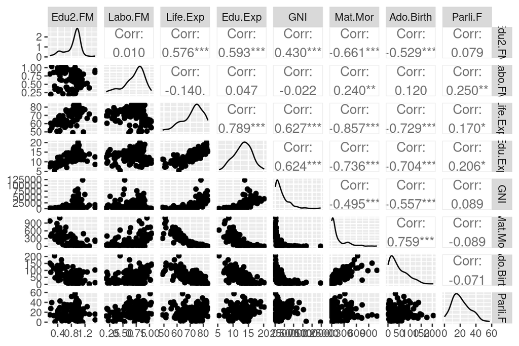

```r
# Access GGally
library(GGally)

# visualize the 'human_' variables
ggpairs(human, progress = FALSE)
```

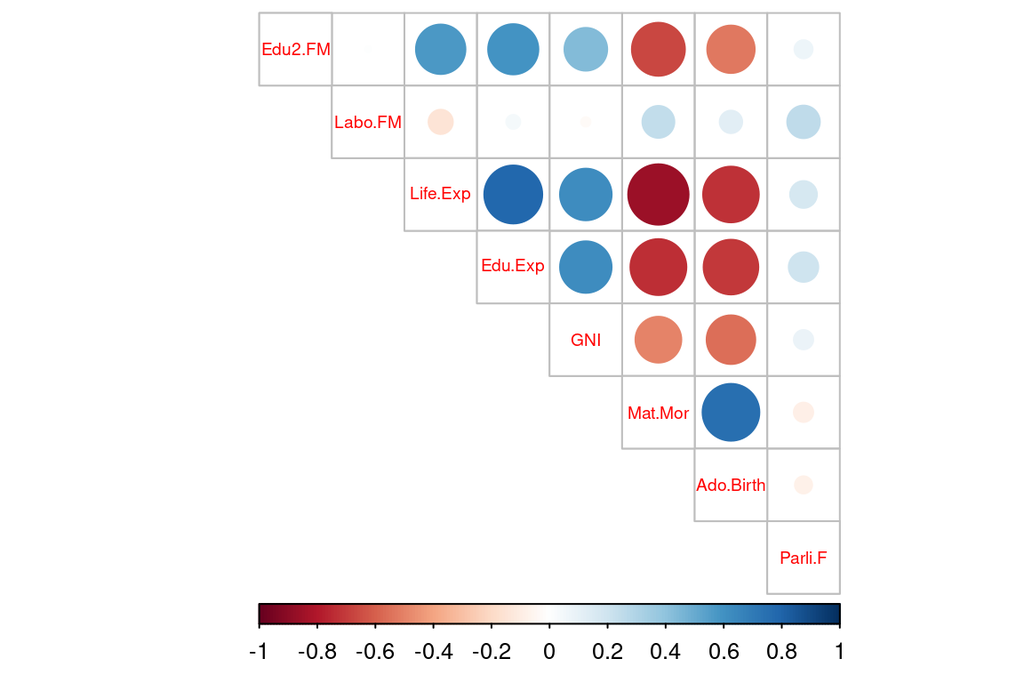

```r
# Access corrplot
library(corrplot)

# compute the correlation matrix and visualize it with corrplot
cor(human) %>% corrplot(method="circle", type="upper", cl.pos="b", tl.pos = "d", tl.cex=0.6)
```

## PCA with raw data

Next, I perform a principal component analysis on the raw data set using `prcomp`, print out the summary that shows the variability captured by the principal components, and then draw a biplot displaying the observations by the first two principal components (PC1 coordinate in x-axis, PC2 coordinate in y-axis), along with arrows representing the original variables,

```r
# perform principal component analysis (with the SVD method)
pca_human <- prcomp(human)

# print out the summary of the pca
s <- summary(pca_human)
s
```

```
## Importance of components:
##                              PC1      PC2   PC3   PC4   PC5   PC6    PC7    PC8
## Standard deviation     1.854e+04 185.5219 25.19 11.45 3.766 1.566 0.1912 0.1591
## Proportion of Variance 9.999e-01   0.0001  0.00  0.00 0.000 0.000 0.0000 0.0000
## Cumulative Proportion  9.999e-01   1.0000  1.00  1.00 1.000 1.000 1.0000 1.0000
```

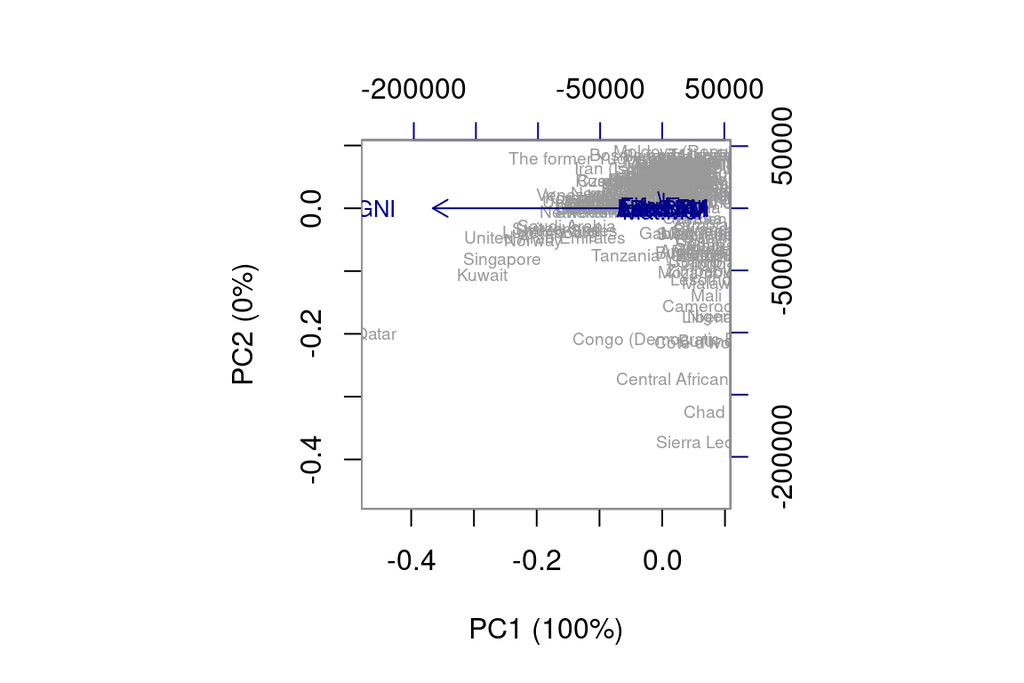

**Figure 1**: Biplot of PCA of the raw data set. The first principal component explains all the variance in the data, corresponding to the gross national income per capita of a given country.

```r
# rounded percentanges of variance captured by each PC
pca_pr <- round(100*s$importance[2, ], digits = 1)

# create object pc_lab to be used as axis labels
pc_lab <- paste0(names(pca_pr), " (", pca_pr, "%)")

# draw a biplot
biplot(pca_human, cex = c(0.6, 0.8), col = c("grey60", "darkblue"), xlab = pc_lab[1], ylab = pc_lab[2])
```

With the raw data, all the variance accumulates to one principal component. This might be related to the fact that the numerical values of `GNI` are much larger compared to those of the other variables. Standardizing the data set should fix this.

## PCA with standardized data

Let’s standardize the data set and perform the PCA again,

```r
# standardize the variables
human_std <- scale(human)

# print out the summaries of the standardized variables
summary(human_std)
```

```
##     Edu2.FM           Labo.FM           Life.Exp          Edu.Exp
##  Min.   :-2.8189   Min.   :-2.6247   Min.   :-2.7188   Min.   :-2.7378
##  1st Qu.:-0.5233   1st Qu.:-0.5484   1st Qu.:-0.6425   1st Qu.:-0.6782
##  Median : 0.3503   Median : 0.2316   Median : 0.3056   Median : 0.1140
##  Mean   : 0.0000   Mean   : 0.0000   Mean   : 0.0000   Mean   : 0.0000
##  3rd Qu.: 0.5958   3rd Qu.: 0.7350   3rd Qu.: 0.6717   3rd Qu.: 0.7126
##  Max.   : 2.6646   Max.   : 1.6632   Max.   : 1.4218   Max.   : 2.4730
##       GNI             Mat.Mor          Ado.Birth          Parli.F
##  Min.   :-0.9193   Min.   :-0.6992   Min.   :-1.1325   Min.   :-1.8203
##  1st Qu.:-0.7243   1st Qu.:-0.6496   1st Qu.:-0.8394   1st Qu.:-0.7409
##  Median :-0.3013   Median :-0.4726   Median :-0.3298   Median :-0.1403
##  Mean   : 0.0000   Mean   : 0.0000   Mean   : 0.0000   Mean   : 0.0000
##  3rd Qu.: 0.3712   3rd Qu.: 0.1932   3rd Qu.: 0.6030   3rd Qu.: 0.6127
##  Max.   : 5.6890   Max.   : 4.4899   Max.   : 3.8344   Max.   : 3.1850
```

```r
# perform principal component analysis (with the SVD method)
pca_human_std <- prcomp(human_std)

# print out the summary of the pca
s_std <- summary(pca_human_std)
s_std
```

```
## Importance of components:
##                           PC1    PC2     PC3     PC4     PC5     PC6     PC7
## Standard deviation     2.0708 1.1397 0.87505 0.77886 0.66196 0.53631 0.45900
## Proportion of Variance 0.5361 0.1624 0.09571 0.07583 0.05477 0.03595 0.02634
## Cumulative Proportion  0.5361 0.6984 0.79413 0.86996 0.92473 0.96069 0.98702
##                            PC8
## Standard deviation     0.32224
## Proportion of Variance 0.01298
## Cumulative Proportion  1.00000
```

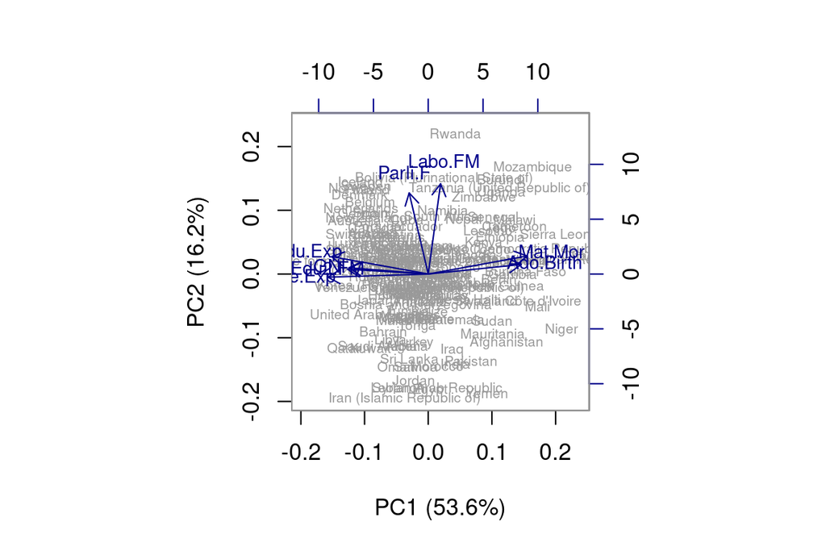

**Figure 2**: Biplot of PCA of the standardized data set. Maternal mortality rate and adolescent birth rate correlate with the first principal component and the quality of education, life expectancy, and gross national income per capita anti-correlate with it. The variables describing gender inequality are orthogonal to these and contribute to the second principal component meaning that gender inequality is an independent feature with respect to healthcare, education, and gross national income. The first PC explains over half of the variance in the data and the second one about 16%.

```r
# rounded percentanges of variance captured by each PC
pca_pr_std <- round(100*s_std$importance[2, ], digits = 1)

# create object pc_lab to be used as axis labels
pc_lab_std <- paste0(names(pca_pr_std), " (", pca_pr_std, "%)")

# draw a biplot
biplot(pca_human_std, cex = c(0.6, 0.8), col = c("grey60", "darkblue"), xlab = pc_lab_std[1], ylab = pc_lab_std[2])
```

Now that the data set is standardized and the numerical values of the variables are all similar, the PCA works much better compared to the one with raw data. Without standardizing, all the variance is explained by the first principal component to which the only contributor is the gross national income per capita, `GNI`, due to its large numerical values. The standardization shifts and rescales the variables so that on the second try I can see the correlations much clearer.

## Interpreting the principal components

In Fig. 2, I plot the result of the principal component analysis of the human data set in terms of the two most significant principal components. In this case, the two principal component dimensions have a quite clear interpretation. The first one, responsible for over half of the variation in the data, is strongly related to the health-related features (`Life.Exp`, `Mat.Mor`, `Ado.Birth`) and the quality of education (`Edu.Exp`, `Edu2.FM`) as well as gross national income per capita (`GNI`), since the corresponding arrows are parallel to the first axis. It clearly describes the poorness of a country: if a given country has a large PC1, its GNI is low and its healthcare and education have a low quality. Here, the low quality of healthcare and poorness is reflected by a low life expectancy, a high maternal mortality rate, and a high adolescent birth rate. The low quality of education, on the other hand, is reflected by low expected years of schooling and a low female-to-male ratio in secondary education. It makes sense that these variables are related: poorer countries with lower GNI have less money to spend on healthcare, birth control, and education leading to lower quality of life. And vice versa, lower quality of life probably leads to low GNI.

The second principal component, responsible of 16% of the variation in the data, describes gender inequality in labour force and parliament (`Labo.FM`, `Parli.F`), as the corresponding arrows align with the second axis. Higher (lower) PC2 can be interpreted as higher inequality in favor of females (males) in labour force and parliament. Also, not surprisingly, the female-to-male ratio in labour force and parliament are strongly correlated with each other.

Already suggested by the correlation plot in the beginning, it seems that gender inequality is not connected to the poorness of a country since the arrows describing these two qualities in Fig. 2 are almost perpendicular to each other. I can’t come up with a simple explanation why that’s the case but it is still an interesting observation.

## MCA on tea data

As the second data set, I analyze tea consumption containing categorical variables. The tool for this is the Multiple Correspondence Analysis (MCA), a multivariate statistical technique used for analyzing relationships in categorical data. To begin, I load the data set and print out its structure and dimensions,

```r
# loading the tea data
tea <- read.csv("https://raw.githubusercontent.com/KimmoVehkalahti/Helsinki-Open-Data-Science/master/datasets/tea.csv", stringsAsFactors = TRUE)

# print out the structure and dimensions
str(tea)
```

```
## 'data.frame':    300 obs. of  36 variables:
##  $ breakfast       : Factor w/ 2 levels "breakfast","Not.breakfast": 1 1 2 2 1 2 1 2 1 1 ...
##  $ tea.time        : Factor w/ 2 levels "Not.tea time",..: 1 1 2 1 1 1 2 2 2 1 ...
##  $ evening         : Factor w/ 2 levels "evening","Not.evening": 2 2 1 2 1 2 2 1 2 1 ...
##  $ lunch           : Factor w/ 2 levels "lunch","Not.lunch": 2 2 2 2 2 2 2 2 2 2 ...
##  $ dinner          : Factor w/ 2 levels "dinner","Not.dinner": 2 2 1 1 2 1 2 2 2 2 ...
##  $ always          : Factor w/ 2 levels "always","Not.always": 2 2 2 2 1 2 2 2 2 2 ...
##  $ home            : Factor w/ 2 levels "home","Not.home": 1 1 1 1 1 1 1 1 1 1 ...
##  $ work            : Factor w/ 2 levels "Not.work","work": 1 1 2 1 1 1 1 1 1 1 ...
##  $ tearoom         : Factor w/ 2 levels "Not.tearoom",..: 1 1 1 1 1 1 1 1 1 2 ...
##  $ friends         : Factor w/ 2 levels "friends","Not.friends": 2 2 1 2 2 2 1 2 2 2 ...
##  $ resto           : Factor w/ 2 levels "Not.resto","resto": 1 1 2 1 1 1 1 1 1 1 ...
##  $ pub             : Factor w/ 2 levels "Not.pub","pub": 1 1 1 1 1 1 1 1 1 1 ...
##  $ Tea             : Factor w/ 3 levels "black","Earl Grey",..: 1 1 2 2 2 2 2 1 2 1 ...
##  $ How             : Factor w/ 4 levels "alone","lemon",..: 1 3 1 1 1 1 1 3 3 1 ...
```

[output cut: 22 more lines]

```r
# view contents of the data
View(tea)
```

The data contains 300 observations of 36 variables collected with a questionnaire on tea consumption. In particular, the participants were asked how they drink tea (18 questions) the what are their product’s perception (12 questions). In addition, some personal details were asked (4 questions). The number of variables is fairly high, and I want to focus only on some of them. I choose the following variables:

- `Tea`: Type of tea,
- `How`: Something mixed with tea,
- `how`: Bagged tea or unpackaged tea or both,
- `sugar`: Sugar with tea,
- `where`: Place of purchase,
- `lunch`: Drank at lunch.

So, let’s keep only the chosen variables in the data set and visualize their distributions,

```r
# column names to keep in the dataset
keep_columns <- c("Tea", "How", "how", "sugar", "where", "lunch")

# select the 'keep_columns' to create a new dataset
tea <- dplyr::select(tea, keep_columns)
```

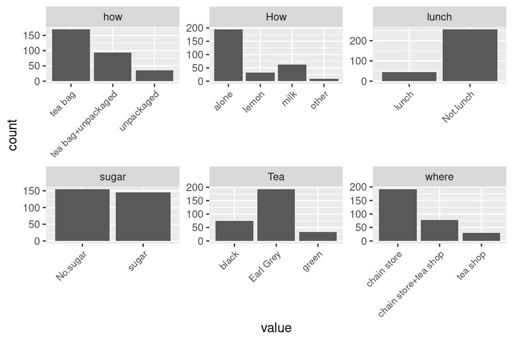

```r
# visualize the dataset
library(tidyr)
library(ggplot2)
pivot_longer(tea, cols = everything()) %>%
  ggplot(aes(value)) + facet_wrap("name", scales = "free") + geom_bar() + theme(axis.text.x = element_text(angle = 45, hjust = 1, size = 8))
```

Next, I perform the MCA for the tea data using the `MCA` function from the `FactoMineR` library and print out the summary of the analysis,

```r
# multiple correspondence analysis
library(FactoMineR)
mca <- MCA(tea, graph = FALSE)

# summary of the model
summary(mca)
```

```
##
## Call:
## MCA(X = tea, graph = FALSE)
##
##
## Eigenvalues
##                        Dim.1   Dim.2   Dim.3   Dim.4   Dim.5   Dim.6   Dim.7
## Variance               0.279   0.261   0.219   0.189   0.177   0.156   0.144
## % of var.             15.238  14.232  11.964  10.333   9.667   8.519   7.841
## Cumulative % of var.  15.238  29.471  41.435  51.768  61.434  69.953  77.794
##                        Dim.8   Dim.9  Dim.10  Dim.11
## Variance               0.141   0.117   0.087   0.062
## % of var.              7.705   6.392   4.724   3.385
## Cumulative % of var.  85.500  91.891  96.615 100.000
##
## Individuals (the 10 first)
##                       Dim.1    ctr   cos2    Dim.2    ctr   cos2    Dim.3
## 1                  | -0.298  0.106  0.086 | -0.328  0.137  0.105 | -0.327
## 2                  | -0.237  0.067  0.036 | -0.136  0.024  0.012 | -0.695
## 3                  | -0.369  0.162  0.231 | -0.300  0.115  0.153 | -0.202
## 4                  | -0.530  0.335  0.460 | -0.318  0.129  0.166 |  0.211
## 5                  | -0.369  0.162  0.231 | -0.300  0.115  0.153 | -0.202
## 6                  | -0.369  0.162  0.231 | -0.300  0.115  0.153 | -0.202
## 7                  | -0.369  0.162  0.231 | -0.300  0.115  0.153 | -0.202
## 8                  | -0.237  0.067  0.036 | -0.136  0.024  0.012 | -0.695
## 9                  |  0.143  0.024  0.012 |  0.871  0.969  0.435 | -0.067
## 10                 |  0.476  0.271  0.140 |  0.687  0.604  0.291 | -0.650
##                       ctr   cos2
## 1                   0.163  0.104 |
## 2                   0.735  0.314 |
## 3                   0.062  0.069 |
## 4                   0.068  0.073 |
## 5                   0.062  0.069 |
## 6                   0.062  0.069 |
## 7                   0.062  0.069 |
## 8                   0.735  0.314 |
## 9                   0.007  0.003 |
## 10                  0.643  0.261 |
##
## Categories (the 10 first)
```

[output cut: 16 more lines]

```
## lemon                3.226 |   1.329  14.771   0.218   8.081 |
## milk                 2.422 |   0.013   0.003   0.000   0.116 |
## other                5.534 |  -2.524  14.526   0.197  -7.676 |
## tea bag             -6.941 |  -0.065   0.183   0.006  -1.287 |
## tea bag+unpackaged  11.956 |   0.019   0.009   0.000   0.226 |
## unpackaged          -6.482 |   0.257   0.602   0.009   1.640 |
##
## Categorical variables (eta2)
##                      Dim.1 Dim.2 Dim.3
## Tea                | 0.126 0.108 0.410 |
## How                | 0.076 0.190 0.394 |
## how                | 0.708 0.522 0.010 |
## sugar              | 0.065 0.001 0.336 |
## where              | 0.702 0.681 0.055 |
## lunch              | 0.000 0.064 0.111 |
```

Finally, let’s plot the result of the MCA as a biplot including only the different categories and hiding the individual observations (with `invisible=c("ind")`),

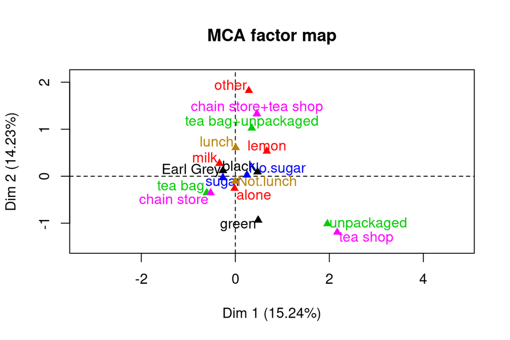

```r
# visualize MCA
plot(mca, invisible=c("ind"), graph.type = "classic", habillage = "quali")
```

The axes in MCA biplot represent the principal components or dimensions and each axis captures a certain proportion of the total variability in the categorical data. In this case, I plot the two dimensions that have the largest contribution to the variance in the data (15% and 14%). The first dimension appears to describe the place of purchase and the type of the tea. Larger values mean that the tea has been purchased from a tea shop and the type is unpackaged and lower values correspond to chain stores as the buying place and tea bags as the type. This also indicates that tea shops sell more unpackaged tea and chain stores sell more tea bags.

The interpretation of the second dimension is not so obvious. One possible interpretation is that it describes how picky or “serious” a tea consumer is: larger values correspond to less serious drinker that buys their tea from any shop (either chain store or tea shop) and might even drink it by mixing it with some other ingredient. On the other hand, lower values correspond to a serious tea consumer that buys their tea (preferably green) only from a proper tea shop.

# Analysis of longitudinal data (Week 6)

In this Analysis exercise, I analyze two data sets containing longitudinal data.

## RATS data

RATS data set contains data from a nutrition study conducted in three groups of rats (Crowder and Hand, 1990). The three groups were put on different diets, and each animal’s body weight (grams) was recorded repeatedly (approximately weekly, except in week seven when two recordings were taken) over a 9-week period. The question of most interest is whether the growth profiles of the three groups differ.

### Loading the data

First, I load the RATS data set, convert the categorical variables to factors, and explore its structure and dimensions,

```r
# Load necessary libraries
library(dplyr)
library(tidyr)
library(readr)

# load the data
RATSL <- read_csv("data/RATSL.csv")
# convert the categorical variables to factors
RATSL$ID <- factor(RATSL$ID)
RATSL$Group <- factor(RATSL$Group)

# print out structure and dimenstions
str(RATSL)
```

```
## spc_tbl_ [176 × 5] (S3: spec_tbl_df/tbl_df/tbl/data.frame)
##  $ ID    : Factor w/ 16 levels "1","2","3","4",..: 1 2 3 4 5 6 7 8 9 10 ...
##  $ Group : Factor w/ 3 levels "1","2","3": 1 1 1 1 1 1 1 1 2 2 ...
##  $ WD    : chr [1:176] "WD1" "WD1" "WD1" "WD1" ...
##  $ Weight: num [1:176] 240 225 245 260 255 260 275 245 410 405 ...
##  $ Time  : num [1:176] 1 1 1 1 1 1 1 1 1 1 ...
##  - attr(*, "spec")=
##   .. cols(
##   ..   ID = col_double(),
##   ..   Group = col_double(),
##   ..   WD = col_character(),
##   ..   Weight = col_double(),
##   ..   Time = col_double()
##   .. )
##  - attr(*, "problems")=<externalptr>
```

The relevant variables are:

- `ID`: identification number of a rat,
- `Group`: group of a rat,
- `Weight`: weight of a rat,
- `Time`: time in days.

### Plotting the data

The weights of the rats can be plotted against time,

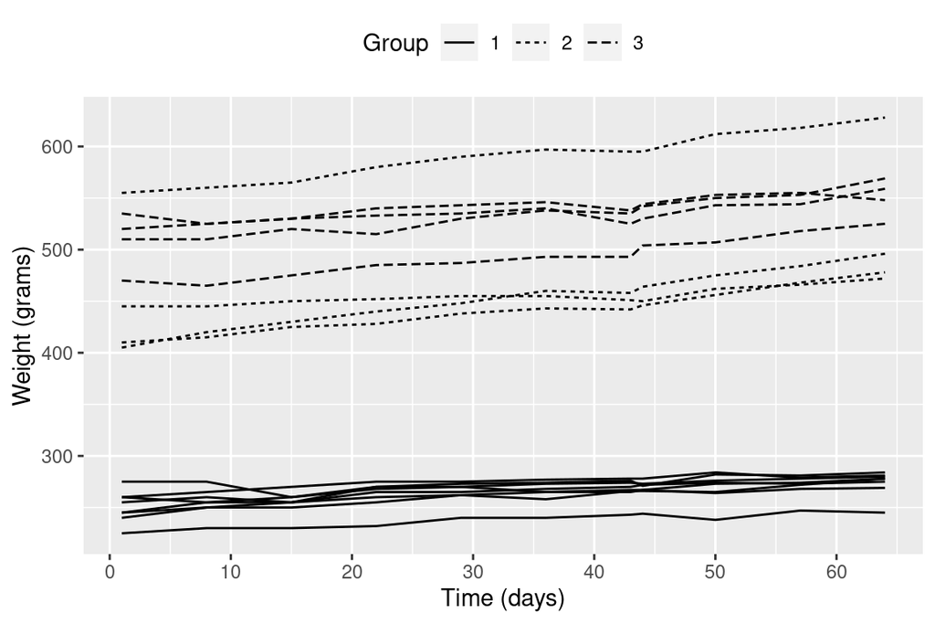

```r
#Access the package ggplot2
library(ggplot2)

# Draw the plot
ggplot(RATSL, aes(x = Time, y = Weight, group = ID)) +
  geom_line(aes(linetype = Group)) +
  scale_x_continuous(name = "Time (days)", breaks = seq(0, 60, 10)) +
  scale_y_continuous(name = "Weight (grams)") +
  theme(legend.position = "top")
```

This simple graph makes a number of features of the data readily apparent. First, the weight of almost all the rats is increasing over the nine weeks of the study. Second, the rats who have higher weights at the beginning tend to have higher values throughout the study. This phenomenon is generally referred to as tracking. Third, group 1 seems to have clearly lower weights throughout the study compared to groups 2 and 3.

The tracking phenomenon can be seen more clearly in a plot of the standardized values of each observation, i.e., the values obtained by subtracting the relevant occasion mean from the original observation and then dividing by the corresponding visit standard deviation. The plot with standardized data is obtained with

```r
# Standardise the variable Weight
RATSL <- RATSL %>%
  group_by(Time) %>%
  mutate(stdWeight = (Weight - mean(Weight))/sd(Weight)) %>%
  ungroup()

# Glimpse the data
glimpse(RATSL)
```

```
## Rows: 176
## Columns: 6
## $ ID        <fct> 1, 2, 3, 4, 5, 6, 7, 8, 9, 10, 11, 12, 13, 14, 15, 16, 1, 2,…
## $ Group     <fct> 1, 1, 1, 1, 1, 1, 1, 1, 2, 2, 2, 2, 3, 3, 3, 3, 1, 1, 1, 1, …
## $ WD        <chr> "WD1", "WD1", "WD1", "WD1", "WD1", "WD1", "WD1", "WD1", "WD1…
## $ Weight    <dbl> 240, 225, 245, 260, 255, 260, 275, 245, 410, 405, 445, 555, …
## $ Time      <dbl> 1, 1, 1, 1, 1, 1, 1, 1, 1, 1, 1, 1, 1, 1, 1, 1, 8, 8, 8, 8, …
## $ stdWeight <dbl> -1.0011429, -1.1203857, -0.9613953, -0.8421525, -0.8819001, …
```

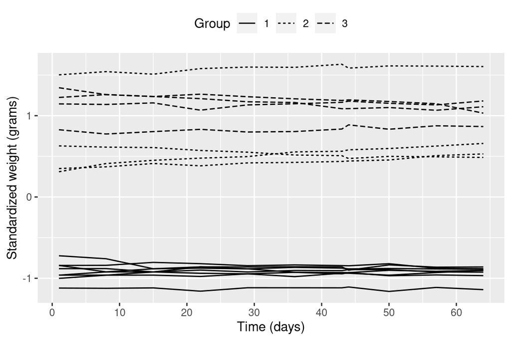

```r
# Plot again with the standardised Weight
ggplot(RATSL, aes(x = Time, y = stdWeight, group = ID)) +
  geom_line(aes(linetype = Group)) +
  scale_x_continuous(name = "Time (days)", breaks = seq(0, 60, 10)) +
  scale_y_continuous(name = "Standardized weight (grams)") +
  theme(legend.position = "top")
```

With large numbers of observations, graphical displays of individual response profiles are of little use and investigators then commonly produce graphs showing average profiles for each nutrition group along with some indication of the variation of the observations at each time point. The mean response profiles for the three groups are given by

```r
# Number of subjects per group:
n <- c(8,4,4)

# Summary data with mean and standard error of Weight by Group and Time
RATSS <- RATSL %>%
  group_by(Group, Time) %>%
  summarise(mean = mean(Weight), se = sd(Weight)/sqrt(n) ) %>%
  ungroup()
# Glimpse the data
glimpse(RATSS)
```

```
## Rows: 99
## Columns: 4
## $ Group <fct> 1, 1, 1, 1, 1, 1, 1, 1, 1, 1, 1, 1, 1, 1, 1, 1, 1, 1, 1, 1, 1, 1…
## $ Time  <dbl> 1, 1, 1, 8, 8, 8, 15, 15, 15, 22, 22, 22, 29, 29, 29, 36, 36, 36…
## $ mean  <dbl> 250.625, 250.625, 250.625, 255.000, 255.000, 255.000, 254.375, 2…
## $ se    <dbl> 5.381640, 7.610789, 7.610789, 4.629100, 6.546537, 6.546537, 4.05…
```

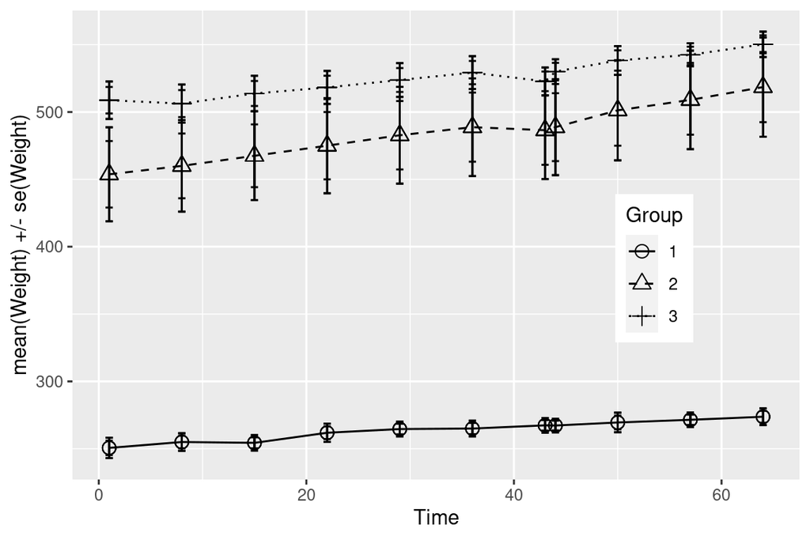

```r
# Plot the mean profiles
ggplot(RATSS, aes(x = Time, y = mean, linetype = Group, shape = Group)) +
  geom_line() +
  scale_linetype_manual(values = c(1,2,3)) +
  geom_point(size=3) +
  scale_shape_manual(values = c(1,2,3)) +
  geom_errorbar(aes(ymin=mean-se, ymax=mean+se, linetype="1"), width=0.7) +
  theme(legend.position = c(0.8,0.45)) +
  scale_y_continuous(name = "mean(Weight) +/- se(Weight)")
```

There is considerable overlap in the mean profiles of the nutrition groups 2 and 3 is suggesting perhaps that there is little difference between the two groups with respect to the mean weights.

### Summary measure analysis

As our first example of the summary measure approach it will be applied to the values of the weights. The mean of weeks 1 to 9 will be the chosen summary measure. We first calculate this measure and then look at boxplots of the measure for each nutrition group. The resulting plot is

```r
# Create a summary data by Group and ID with mean as the summary variable (ignoring baseline time 0)
RATSL8S <- RATSL %>%
  filter(Time > 1) %>%
  group_by(Group, ID) %>%
  summarise( mean=mean(Weight) ) %>%
  ungroup()
# Glimpse the data
glimpse(RATSL8S)
```

```
## Rows: 16
## Columns: 3
## $ Group <fct> 1, 1, 1, 1, 1, 1, 1, 1, 2, 2, 2, 2, 3, 3, 3, 3
## $ ID    <fct> 1, 2, 3, 4, 5, 6, 7, 8, 9, 10, 11, 12, 13, 14, 15, 16
## $ mean  <dbl> 263.2, 238.9, 261.7, 267.2, 270.9, 276.2, 274.6, 267.5, 443.9, 4…
```

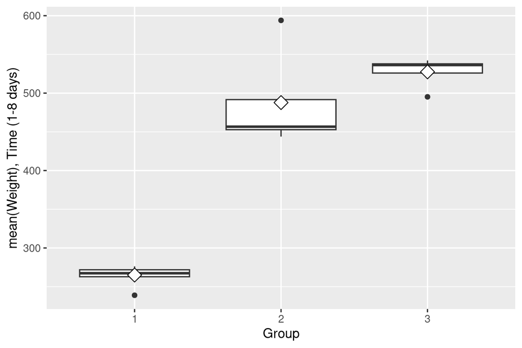

```r
# Draw a boxplot of the mean versus treatment
ggplot(RATSL8S, aes(x = Group, y = mean)) +
  geom_boxplot() +
  stat_summary(fun = "mean", geom = "point", shape=23, size=4, fill = "white") +
  scale_y_continuous(name = "mean(Weight), Time (1-8 days)")
```

The diagram indicates that the mean summary measure is most variable in the second nutrition group and its distribution in this group is somewhat skew. The boxplots of all the groups reveal an outlier. They might bias the conclusions from further comparisons of the groups, so we decide to remove those rats from the data. The new version of the boxplots is

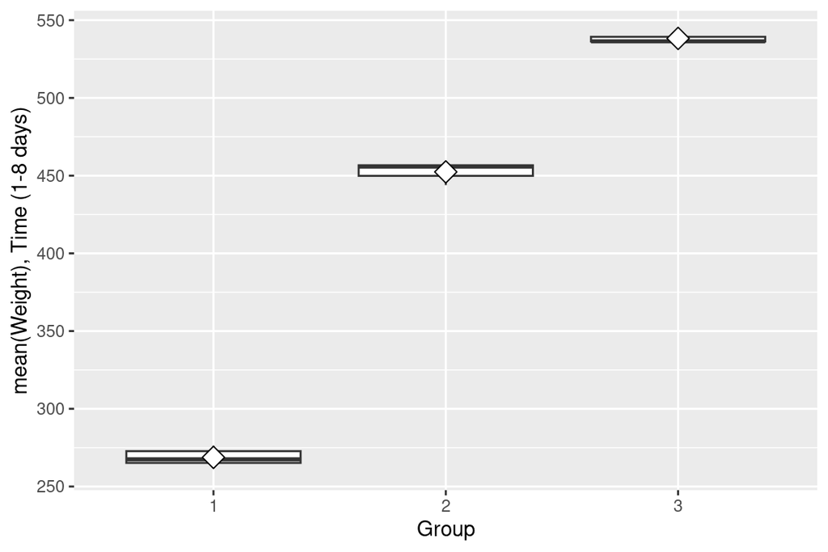

```r
# Create a new data by filtering the outliers and adjust the ggplot code the draw the plot again with the new data
RATSL8S1 <- RATSL8S %>% filter((mean > 240 & Group == 1) | (mean < 590 & Group == 2) | (mean > 500 & Group == 3))

# Draw a boxplot of the mean versus group
ggplot(RATSL8S1, aes(x = Group, y = mean)) +
  geom_boxplot() +
  stat_summary(fun = "mean", geom = "point", shape=23, size=4, fill = "white") +
  scale_y_continuous(name = "mean(Weight), Time (1-8 days)")
```

Without the outliers, there is clear evidence of a difference in location of the summary measure distributions in each group. The difference is mostly a result of the different baselines of each group.

Baseline measurements of the outcome variable in a longitudinal study are often correlated with the chosen summary measure and using such measures in the analysis can often lead to substantial gains in precision when used appropriately as a covariate in an analysis of covariance (see Everitt and Pickles, 2004). We can illustrate the analysis on the RATS data using the weight corresponding to time one (day) taken on the first day of the study as the baseline covariate. The results are

```r
# Add the baseline from the original data as a new variable to the summary data
RATSL8S2 <- RATSL8S %>%
  mutate(baseline = filter(RATSL, Time == 1)$Weight)

# Fit the linear model with the mean as the response
fit <- lm(mean ~ baseline + Group, data = RATSL8S2)

# Compute the analysis of variance table for the fitted model with anova()
anova(fit)
```

```
## Analysis of Variance Table
##
## Response: mean
##           Df Sum Sq Mean Sq   F value   Pr(>F)
## baseline   1 253625  253625 1859.8201 1.57e-14 ***
## Group      2    879     439    3.2219  0.07586 .
## Residuals 12   1636     136
## ---
## Signif. codes:  0 '***' 0.001 '**' 0.01 '*' 0.05 '.' 0.1 ' ' 1
```

We see that the baseline weight is strongly related to the weights measured after the study has begun, but there is no evidence of a nutrition group difference even after conditioning on the baseline value.

## BPRS data

Next, I study data taken from Davis (2002). Here 40 male subjects were randomly assigned to one of two treatment groups and each subject was rated on the brief psychiatric rating scale (BPRS) measured before treatment began (week 0) and then at weekly intervals for eight weeks. The BPRS assesses the level of 18 symptom constructs such as hostility, suspiciousness, hallucinations and grandiosity; each of these is rated from one (not present) to seven (extremely severe). The scale is used to evaluate patients suspected of having schizophrenia.

### Loading the data

First, I load the BPRS data set, convert the categorical variables to factors, and explore its structure and dimensions,

```r
# load the data
BPRSL <- read_csv("data/BPRSL.csv")
# convert the categorical variables to factors
BPRSL$treatment <- factor(BPRSL$treatment)
BPRSL$subject <- factor(BPRSL$subject)

# print out structure and dimenstions
str(BPRSL)
```

```
## spc_tbl_ [360 × 5] (S3: spec_tbl_df/tbl_df/tbl/data.frame)
##  $ treatment: Factor w/ 2 levels "1","2": 1 1 1 1 1 1 1 1 1 1 ...
##  $ subject  : Factor w/ 20 levels "1","2","3","4",..: 1 2 3 4 5 6 7 8 9 10 ...
##  $ weeks    : chr [1:360] "week0" "week0" "week0" "week0" ...
##  $ bprs     : num [1:360] 42 58 54 55 72 48 71 30 41 57 ...
##  $ week     : num [1:360] 0 0 0 0 0 0 0 0 0 0 ...
##  - attr(*, "spec")=
##   .. cols(
##   ..   treatment = col_double(),
##   ..   subject = col_double(),
##   ..   weeks = col_character(),
##   ..   bprs = col_double(),
##   ..   week = col_double()
##   .. )
##  - attr(*, "problems")=<externalptr>
```

The relevant variables are:

- `treatment`: factor determining the treatment group of a subject (1 or 2),
- `subject`: idenfier for a subject,
- `bprs`: BPRS score of a subject,
- `week`: time in weeks.

### Plotting the data

To begin, we will plot the data, identifying the observations in each treatment group,

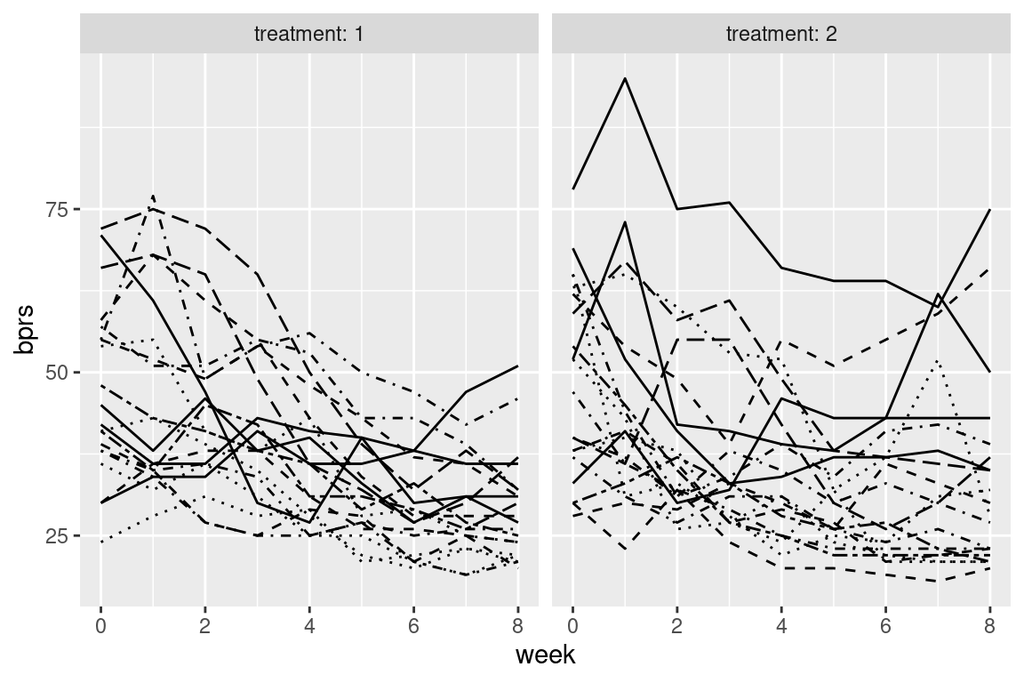

```r
# Draw the plot
ggplot(BPRSL, aes(x = week, y = bprs, linetype = subject)) +
  geom_line() +
  scale_linetype_manual(values = rep(1:10, times=4)) +
  facet_grid(. ~ treatment, labeller = label_both) +
  theme(legend.position = "none") +
  scale_y_continuous(limits = c(min(BPRSL$bprs), max(BPRSL$bprs)))
```

The difference between the two groups does not seem to be obvious.

### Fitting a multiple linear regression model

Ignoring the repeated-measures structure of the data, we might fit a multiple linear regression model with BPRS score as response and time and treatment group as explanatory variables. Fitting the model gives the results

```r
# create a regression model BPRS_reg
BPRS_reg <-  lm(bprs ~ week + treatment, data = BPRSL)

# print out a summary of the model
summary(BPRS_reg)
```

```
##
## Call:
## lm(formula = bprs ~ week + treatment, data = BPRSL)
##
## Residuals:
##     Min      1Q  Median      3Q     Max
## -22.454  -8.965  -3.196   7.002  50.244
##
## Coefficients:
##             Estimate Std. Error t value Pr(>|t|)
## (Intercept)  46.4539     1.3670  33.982   <2e-16 ***
## week         -2.2704     0.2524  -8.995   <2e-16 ***
## treatment2    0.5722     1.3034   0.439    0.661
## ---
## Signif. codes:  0 '***' 0.001 '**' 0.01 '*' 0.05 '.' 0.1 ' ' 1
##
## Residual standard error: 12.37 on 357 degrees of freedom
## Multiple R-squared:  0.1851, Adjusted R-squared:  0.1806
## F-statistic: 40.55 on 2 and 357 DF,  p-value: < 2.2e-16
```

As we might have anticipated from the plot, group 2 does not differ significantly from group 1 conditional on time; however, the regression on time is highly significant. We might go on to fit a model with a treatment group × time interaction, but we will not do this because we know from the structure of the data that the model considered here is wrong. The model assumes independence of the repeated measures of the BPRS score, and this assumption is highly unlikely. So, now we will move on to consider both some more appropriate graphics and appropriate models.

### Random intercept model

This model allows the linear regression fit for each subject to differ in intercept from other subjects. Fitting this model gives the results

```r
# access library lme4
library(lme4)
# Create a random intercept model
BPRS_ref <- lmer(bprs ~ week + treatment + (1 | subject), data = BPRSL, REML = FALSE)

# Print the summary of the model
summary(BPRS_ref)
```

```
## Linear mixed model fit by maximum likelihood  ['lmerMod']
## Formula: bprs ~ week + treatment + (1 | subject)
##    Data: BPRSL
##
##      AIC      BIC   logLik deviance df.resid
##   2748.7   2768.1  -1369.4   2738.7      355
##
## Scaled residuals:
##     Min      1Q  Median      3Q     Max
## -3.0481 -0.6749 -0.1361  0.4813  3.4855
##
## Random effects:
##  Groups   Name        Variance Std.Dev.
##  subject  (Intercept)  47.41    6.885
##  Residual             104.21   10.208
## Number of obs: 360, groups:  subject, 20
##
## Fixed effects:
##             Estimate Std. Error t value
## (Intercept)  46.4539     1.9090  24.334
## week         -2.2704     0.2084 -10.896
## treatment2    0.5722     1.0761   0.532
##
## Correlation of Fixed Effects:
##            (Intr) week
## week       -0.437
## treatment2 -0.282  0.000
```

Now we can move on to fit the random intercept and random slope model to the BPRS score data. The results are

```r
# create a random intercept and random slope model
BPRS_ref1 <- lmer(bprs ~ week + treatment + (week | subject), data = BPRSL, REML = FALSE)

# print a summary of the model
summary(BPRS_ref1)
```

```
## Linear mixed model fit by maximum likelihood  ['lmerMod']
## Formula: bprs ~ week + treatment + (week | subject)
##    Data: BPRSL
##
##      AIC      BIC   logLik deviance df.resid
##   2745.4   2772.6  -1365.7   2731.4      353
##
## Scaled residuals:
##     Min      1Q  Median      3Q     Max
## -2.8919 -0.6194 -0.0691  0.5531  3.7976
##
## Random effects:
##  Groups   Name        Variance Std.Dev. Corr
##  subject  (Intercept) 64.8222  8.0512
##           week         0.9609  0.9802   -0.51
##  Residual             97.4305  9.8707
## Number of obs: 360, groups:  subject, 20
##
## Fixed effects:
##             Estimate Std. Error t value
## (Intercept)  46.4539     2.1052  22.066
## week         -2.2704     0.2977  -7.626
## treatment2    0.5722     1.0405   0.550
##
## Correlation of Fixed Effects:
##            (Intr) week
## week       -0.582
## treatment2 -0.247  0.000
```

```r
# perform an ANOVA test on the two models
anova(BPRS_ref1, BPRS_ref)
```

```
## Data: BPRSL
## Models:
## BPRS_ref: bprs ~ week + treatment + (1 | subject)
## BPRS_ref1: bprs ~ week + treatment + (week | subject)
##           npar    AIC    BIC  logLik deviance  Chisq Df Pr(>Chisq)
## BPRS_ref     5 2748.7 2768.1 -1369.4   2738.7
## BPRS_ref1    7 2745.4 2772.6 -1365.7   2731.4 7.2721  2    0.02636 *
## ---
## Signif. codes:  0 '***' 0.001 '**' 0.01 '*' 0.05 '.' 0.1 ' ' 1
```

The results for the fixed effects are very similar to those in the previous analysis, but the likelihood ratio test for the random intercept model versus the random intercept and slope model gives a chi-squared statistic of 7.27 with 2 degrees of freedom (DF), and the associated p-value is somewhat small. The random intercept and slope model provides a slightly better fit for these data.

Finally, we can fit a random intercept and slope model that allows for a treatment group × time interaction. Fitting this model gives the results

```r
# create a random intercept and random slope model with the interaction
BPRS_ref2 <- lmer(bprs ~ week + treatment + week * treatment + (week | subject), data = BPRSL, REML = FALSE)

# print a summary of the model
summary(BPRS_ref2)
```

```
## Linear mixed model fit by maximum likelihood  ['lmerMod']
## Formula: bprs ~ week + treatment + week * treatment + (week | subject)
##    Data: BPRSL
##
##      AIC      BIC   logLik deviance df.resid
##   2744.3   2775.4  -1364.1   2728.3      352
##
## Scaled residuals:
##     Min      1Q  Median      3Q     Max
## -3.0512 -0.6271 -0.0768  0.5288  3.9260
##
## Random effects:
##  Groups   Name        Variance Std.Dev. Corr
##  subject  (Intercept) 64.9964  8.0620
##           week         0.9687  0.9842   -0.51
##  Residual             96.4707  9.8220
## Number of obs: 360, groups:  subject, 20
##
## Fixed effects:
##                 Estimate Std. Error t value
## (Intercept)      47.8856     2.2521  21.262
## week             -2.6283     0.3589  -7.323
## treatment2       -2.2911     1.9090  -1.200
## week:treatment2   0.7158     0.4010   1.785
##
## Correlation of Fixed Effects:
##             (Intr) week   trtmn2
## week        -0.650
## treatment2  -0.424  0.469
## wek:trtmnt2  0.356 -0.559 -0.840
```

```r
# perform an ANOVA test on the two models
anova(BPRS_ref2, BPRS_ref1)
```

```
## Data: BPRSL
## Models:
## BPRS_ref1: bprs ~ week + treatment + (week | subject)
## BPRS_ref2: bprs ~ week + treatment + week * treatment + (week | subject)
##           npar    AIC    BIC  logLik deviance  Chisq Df Pr(>Chisq)
## BPRS_ref1    7 2745.4 2772.6 -1365.7   2731.4
## BPRS_ref2    8 2744.3 2775.4 -1364.1   2728.3 3.1712  1    0.07495 .
## ---
## Signif. codes:  0 '***' 0.001 '**' 0.01 '*' 0.05 '.' 0.1 ' ' 1
```

The likelihood ratio test of the interaction random intercept and slope model against the corresponding model without an interaction is 3.17 with 1 DF; the associated p-value is somewhat small, and we can conclude that the interaction model provides a very slightly better fit for the BPRS score data. The estimated regression parameters for the interaction indicate that the BPRS score slopes are higher for subjects in treatment group 2 than for subjects in group 1: on average 0.72 higher with an approximate 95% confidence interval [CI] of [-0.08, 1.52]. Since zero is included in the confidence interval, one can not claim to have any significant difference between the two treatment groups.

We can find the fitted values from the interaction model and plot the fitted BPRS scores for each subject. The observed and fitted values are plotted as

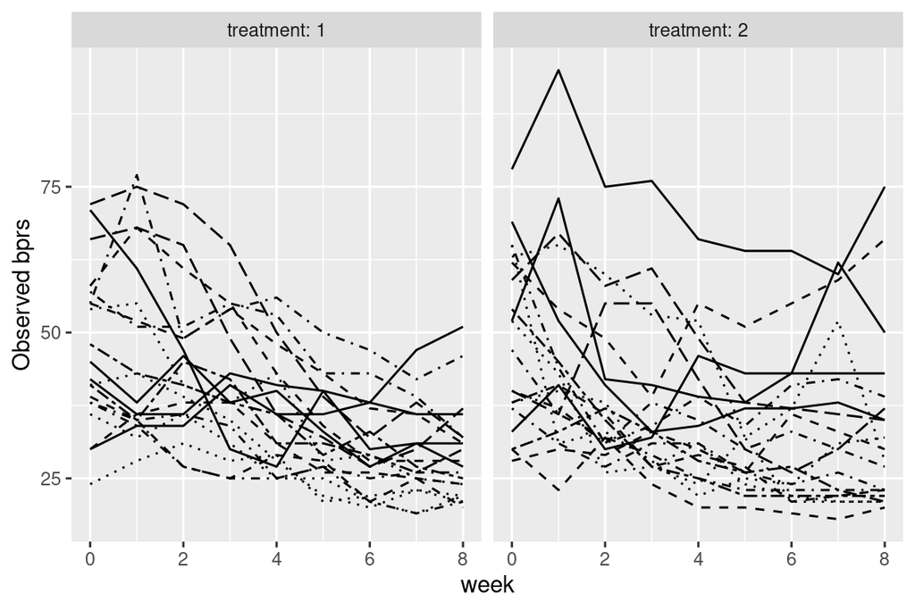

```r
# draw the plot of BPRSL with the observed bprs values
ggplot(BPRSL, aes(x = week, y = bprs, linetype = subject)) +
  geom_line() +
  scale_linetype_manual(values = rep(1:10, times=4)) +
  facet_grid(. ~ treatment, labeller = label_both) +
  theme(legend.position = "none") +
  scale_y_continuous(limits = c(min(BPRSL$bprs), max(BPRSL$bprs)), name = "Observed bprs")
```

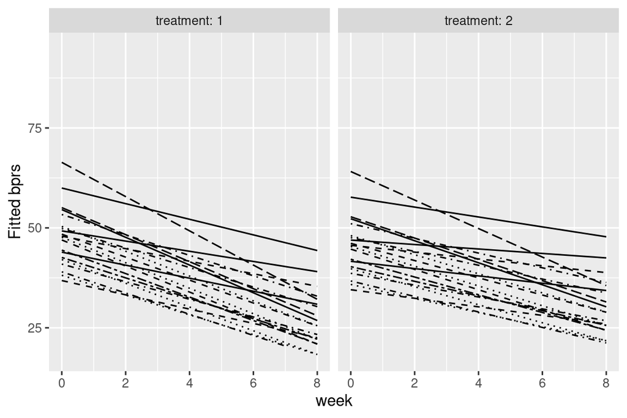

```r
# Create a vector of the fitted values
Fitted <- fitted(BPRS_ref2)

# Create a new column fitted to BPRSL
BPRSL <- BPRSL %>% mutate(Fitted = Fitted)

# draw the plot of BPRSL with the Fitted values of weight
ggplot(BPRSL, aes(x = week, y = Fitted, linetype = subject)) +
  geom_line() +
  scale_linetype_manual(values = rep(1:10, times=4)) +
  facet_grid(. ~ treatment, labeller = label_both) +
  theme(legend.position = "none") +
  scale_y_continuous(limits = c(min(BPRSL$bprs), max(BPRSL$bprs)), name = "Fitted bprs")
```

This graphic shows that the interaction model fails to fit the observed data with high precision. Perhaps there are some nonlinear effects in the observed data not captured by the linear model.